# Data Visualisation - Space Data

```python
pip install plotly
```

```python
pip install iso3166
```

```python
import pandas as pd
import numpy as np
import plotly.express as px
from iso3166 import countries
import plotly.graph_objects as go
import seaborn as sns
import matplotlib.pyplot as plt
from collections import Counter
from plotly import __version__
from plotly.offline import download_plotlyjs, init_notebook_mode, plot, iplot
from calendar import month_abbr
import plotly.figure_factory as ff
from pywaffle import Waffle
from plotly.subplots import make_subplots
from datetime import datetime
pd.plotting.register_matplotlib_converters()
import squarify
import cufflinks as cf
init_notebook_mode(connected=True)
cf.go_offline()
from sklearn.decomposition import PCA
from sklearn import datasets
```

```python
space_data = pd.read_csv("C:/Users/saumy/Desktop/Space_3.csv")
space_data
```

|  | Unnamed: 0 | Unnamed: 0.1 | Company Name | Location | Datum | Detail | Status Rocket | Rocket | Status Mission | Country | ... | Days | Date | Year | Month | Date_Time | weekday | Region | States | center | Rocket Name |
| --- | --- | --- | --- | --- | --- | --- | --- | --- | --- | --- | --- | --- | --- | --- | --- | --- | --- | --- | --- | --- | --- |
| 0 | 0 | 0 | SpaceX | LC-39A, Kennedy Space Center, Florida, USA | Fri Aug 07, 2020 05:12 UTC | Falcon 9 Block 5 \| Starlink V1 L9 & BlackSky | StatusActive | 50.0 | Success | USA | ... | Friday | 2020-08-07 | 2020 | 8 | 2020-08-07 05:12:00 | 4 | Florida, USA | Florida | Kennedy Space Center | Falcon 9 Block 5 |
| 1 | 1 | 1 | CASC | Site 9401 (SLS-2), Jiuquan Satellite Launch Ce... | Thu Aug 06, 2020 04:01 UTC | Long March 2D \| Gaofen-9 04 & Q-SAT | StatusActive | 29.75 | Success | China | ... | Thursday | 2020-08-06 | 2020 | 8 | 2020-08-06 04:01:00 | 3 | Jiuquan Satellite Launch Center, China | Jiuquan Satellite Launch Center | Jiuquan Satellite Launch Center | Long March 2D |
| 2 | 2 | 2 | SpaceX | Pad A, Boca Chica, Texas, USA | Tue Aug 04, 2020 23:57 UTC | Starship Prototype \| 150 Meter Hop | StatusActive | NaN | Success | USA | ... | Tuesday | 2020-08-04 | 2020 | 8 | 2020-08-04 23:57:00 | 1 | Texas, USA | Texas | Boca Chica | Starship Prototype |
| 3 | 3 | 3 | Roscosmos | Site 200/39, Baikonur Cosmodrome, Kazakhstan | Thu Jul 30, 2020 21:25 UTC | Proton-M/Briz-M \| Ekspress-80 & Ekspress-103 | StatusActive | 65.0 | Success | Kazakhstan | ... | Thursday | 2020-07-30 | 2020 | 7 | 2020-07-30 21:25:00 | 3 | Baikonur Cosmodrome, Kazakhstan | Baikonur Cosmodrome | Baikonur Cosmodrome | Proton-M/Briz-M |
| 4 | 4 | 4 | ULA | SLC-41, Cape Canaveral AFS, Florida, USA | Thu Jul 30, 2020 11:50 UTC | Atlas V 541 \| Perseverance | StatusActive | 145.0 | Success | USA | ... | Thursday | 2020-07-30 | 2020 | 7 | 2020-07-30 11:50:00 | 3 | Florida, USA | Florida | Cape Canaveral AFS | Atlas V 541 |
| ... | ... | ... | ... | ... | ... | ... | ... | ... | ... | ... | ... | ... | ... | ... | ... | ... | ... | ... | ... | ... | ... |
| 4319 | 4319 | 4319 | US Navy | LC-18A, Cape Canaveral AFS, Florida, USA | Wed Feb 05, 1958 07:33 UTC | Vanguard \| Vanguard TV3BU | StatusRetired | NaN | Failure | USA | ... | Wednesday | 1958-02-05 | 1958 | 2 | 1958-02-05 07:33:00 | 2 | Florida, USA | Florida | Cape Canaveral AFS | Vanguard |
| 4320 | 4320 | 4320 | AMBA | LC-26A, Cape Canaveral AFS, Florida, USA | Sat Feb 01, 1958 03:48 UTC | Juno I \| Explorer 1 | StatusRetired | NaN | Success | USA | ... | Saturday | 1958-02-01 | 1958 | 2 | 1958-02-01 03:48:00 | 5 | Florida, USA | Florida | Cape Canaveral AFS | Juno I |
| 4321 | 4321 | 4321 | US Navy | LC-18A, Cape Canaveral AFS, Florida, USA | Fri Dec 06, 1957 16:44 UTC | Vanguard \| Vanguard TV3 | StatusRetired | NaN | Failure | USA | ... | Friday | 1957-12-06 | 1957 | 12 | 1957-12-06 16:44:00 | 4 | Florida, USA | Florida | Cape Canaveral AFS | Vanguard |
| 4322 | 4322 | 4322 | RVSN USSR | Site 1/5, Baikonur Cosmodrome, Kazakhstan | Sun Nov 03, 1957 02:30 UTC | Sputnik 8K71PS \| Sputnik-2 | StatusRetired | NaN | Success | Russia | ... | Sunday | 1957-11-03 | 1957 | 11 | 1957-11-03 02:30:00 | 6 | Baikonur Cosmodrome, Kazakhstan | Baikonur Cosmodrome | Baikonur Cosmodrome | Sputnik 8K71PS |
| 4323 | 4323 | 4323 | RVSN USSR | Site 1/5, Baikonur Cosmodrome, Kazakhstan | Fri Oct 04, 1957 19:28 UTC | Sputnik 8K71PS \| Sputnik-1 | StatusRetired | NaN | Success | Russia | ... | Friday | 1957-10-04 | 1957 | 10 | 1957-10-04 19:28:00 | 4 | Baikonur Cosmodrome, Kazakhstan | Baikonur Cosmodrome | Baikonur Cosmodrome | Sputnik 8K71PS |

4324 rows × 24 columns

```python
del space_data["Unnamed: 0.1"]
```

```python
space = space_data.copy()
space["Unnamed: 0"] = (space["Unnamed: 0"] + 1 - max(space["Unnamed: 0"]))*(-1)+2
space.rename(columns = {'Rocket Name':'Rocket Type','Rocket':'Rocket Price',"Unnamed: 0" : "Launch Number"}, inplace = True)
space["Rocket Type"] = space["Detail"].map(lambda name : name.split("|")[0].strip())
space["Launcher"] = space["Location"].map(lambda loc : loc.split(",")[0].strip())
space["Site name"] = space["Location"].map(lambda loc : loc.split(",")[1].strip())
sites = ['Xichang Satellite Launch Center','Imam Khomeini Spaceport','Blue Origin Launch Site',
         'Taiyuan Satellite Launch Center','Tai Rui Barge','Uchinoura Space Center',
         'Jiuquan Satellite Launch Center','Svobodny Cosmodrome']
ind = []
for site in sites:
    space["Site name"].iloc[space[space["Launcher"] == site].index] = site

space.replace('Alc?›ntara Launch Center','Alcantara Launch Center',inplace = True)
space.replace('M?\x81hia Peninsula','Mahia Peninsula',inplace = True)
```

How the launch has grown from the first launch to today ?

Evolution of Launches

```python
fig = px.line(space, x='Dates', y="Launch Number",title="Evaluation of Launches",color_discrete_sequence = px.colors.qualitative.G10, template = "plotly",width=1000,height = 600)
fig.show()
```

[interactive chart not shown]

The evolution is close to being linear. This reflect the constant interest in space discovery. However, the curve seems to have a higher growing rate before 1980 and in order to see more accurate this evolution, I will use a bar plot to compare each year

Number of launches per year

```python
Count_Year =space["Year"].value_counts().reset_index().rename(columns={"index" : "Year","Year" : "Count"}).sort_values("Year")
fig = px.bar(Count_Year, y='Count', x='Year', text='Count', color = 'Count',color_continuous_scale= 'Emrld',title="Number of evaluation of launches",
             template = "plotly",height = 600)
fig.show()
```

[interactive chart not shown]

The space Missions were started earlier 1957 but the first satellite Sputnik 1 was launched in 1957 from then on many missions have been and still going on. There was a huge increment in the number of missions from 1961-1978 probably because of the moon missions. In 1969, astronaut Neil Armstrong took “one giant leap for mankind” as he stepped onto the moon. Six Apollo missions were made to explore the moon between 1969 and 1972.

The evolution is well noticeable with this graph and particularly the different between the years !

We can observe 3 important variation on it :

The highest evolution from 1957 to 1978 corresponding to one portion of the Cold War The number of launch dropped drastically until 2015 and have been almost divided by two in comparison to the previous period A new growth since 2016 !

Number of Launches per year and by country

```python
Count_Year_country = space.groupby(["Year","Country","alpha3"])["Launch Number"].count().reset_index()

fig = px.bar(Count_Year_country, y='Launch Number', x='Year',color="Country",
             color_discrete_sequence = px.colors.qualitative.G10,template = "plotly", title = "Number of Launches per year and by country",
             height = 600)
fig.show()
```

[interactive chart not shown]

Geographic evolution of launches number per year and by country

```python
fig = px.scatter_geo(Count_Year_country,locations = "alpha3",
                     hover_name="Country",
                     size="Launch Number",
                     color = "Launch Number",
                     title = "Geographic evolution of launches number per year and by country",
                     animation_frame="Year",
                     projection="natural earth",
                     color_continuous_scale= 'Bluered_r',
                     template = "plotly",
                     width = 1000,height = 600)
fig.show()
```

[interactive chart not shown]

Click on play button ! This animation shows us the evolution and distribution of launches number per country since 1957.

It's an other way to see again that Russia and the USA represented the biggest part of launches !

It's important to take into account that the launches was not in the country marked, but just organized by these ones. For example, French rocket are launched from Guyane (one of its regions) which is in South America.

```python
fig = px.sunburst(space_data, path = ['Country','Company Name'], title = 'Country and their Space Organisations',width =1000,height = 700)
fig.show()
```

[interactive chart not shown]

Number of launches by every company

```python
ds = space_data['Company Name'].value_counts().reset_index()
ds.columns = [
    'company',
    'Number of launches'
]
ds = ds.sort_values(['Number of launches'])
fig = px.bar(
    ds,
    x='Number of launches',
    y="company",
    orientation='h',
    title='Number of launches by every company',
    width=1100,
    height=1000 ,
    template = "plotly"
)
fig.show()
```

[interactive chart not shown]

```python
def plot_map(dataframe, target_column, title, width=1000, height=600):
    mapdf = dataframe.groupby(['Country', 'alpha3'])[target_column].count().reset_index()
    fig = px.choropleth(
        mapdf,
        locations="alpha3",
        hover_name="Country",
        color=target_column,
        projection="natural earth",
        width=width,
        height=height,
        title=title,
        template = "plotly"
    )
    fig.show()
```

```python
plot_map(
    dataframe=space_data,
    target_column='Status Mission',
    title='Number of launches per country'
)
```

[interactive chart not shown]

Company performance year wise

```python
companies = space_data.groupby(['Company Name'])['Detail'].count().sort_values(ascending=False).reset_index()
year_wise = space_data.groupby(['Company Name','Year']).count()['Detail'].reset_index()
year_wise = year_wise[year_wise['Company Name'].isin(companies['Company Name'][:20])]

fig = go.Figure(data=go.Heatmap(
        z=year_wise['Detail'],
        x=year_wise['Year'],
        y=year_wise['Company Name'],
        colorscale='Viridis'))

fig.update_layout(
    title='Company wise launches  per year',
    xaxis_nticks=36)

fig.show()
```

[interactive chart not shown]

RVSN USSR is the first company to venture into space industry and the performance was incredible with increasing number of launches every year and is the only compamy to lauch 97 missions in a single year(1977) until it was collapsed in 1991. There were not many companies in the space research at the beginning(1957) but we can see a tremendous increase in the companies now(2020). These companies not only ventured but also maintained consistency in number of launches per year (SpaceX, VKS RF, Arianespace, ISRO)

Country performance over the years

```python
year_wise = space_data.groupby(['Country','Year']).count()['Detail'].reset_index()
fig = go.Figure(data=go.Heatmap(
        z=year_wise['Detail'],
        x=year_wise['Year'],
        y=year_wise['Country'],
        colorscale='Viridis'))
fig.update_layout(
    title='Country wise launches  per year',
    xaxis_nticks=36)
fig.show()
```

[interactive chart not shown]

Contries and their Rocket Launch Pad

```python
fig = px.sunburst(space_data,path = ['Country','States'],height = 700,title = 'Contries and their Rocket Launch Pad')
fig.show()
```

[interactive chart not shown]

Launch Vehicle used for number of missions

```python
ro = space_data['Rocket Name'].value_counts().sort_values(ascending=True)[-50:]
fig = go.Figure(go.Bar(x=ro.values, y=ro.keys(),orientation='h'))
fig.update_layout(title="Launch Vehicle used for number of missions ")
```

[interactive chart not shown]

Geographical plot of Countries and their Launches

```python
country = space_data.groupby('Country').count()['Detail'].sort_values(ascending=False).reset_index()
country.rename(columns={"Detail":"No of Launches"},inplace=True)
country.head(10).style.background_gradient(cmap='Blues').hide_index()

map_data = [go.Choropleth(
           locations = country['Country'],
           locationmode = 'country names',
           z = country["No of Launches"],
           text = country['Country'],
           colorbar = {'title':'No of Launches'},
           colorscale='ylorrd')]

layout = dict(title = 'Countries wise Rocket Launches',
             geo = dict(showframe = False,
             projection = dict(type = 'equirectangular')))

world_map = go.Figure(data=map_data, layout=layout)
iplot(world_map)
```

[interactive chart not shown]

Centers with maximum number of Launches

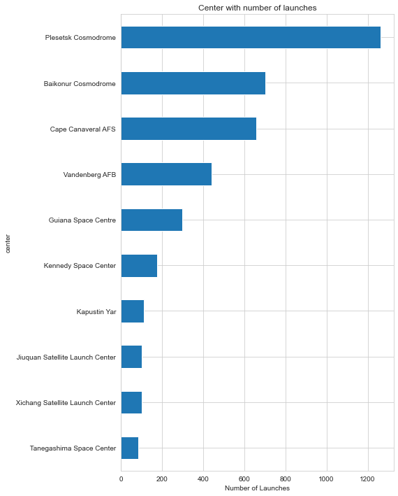

```python
space_data.groupby('center').count()['Detail'].sort_values()[-10:].plot(kind='barh')
plt.xlabel('Number of Launches')
t=plt.title('Center with number of launches')
```

In which years countries were more active?

```python
top_10 = country['Country'].head(10)
x= space_data.groupby(['Year','Country']).count().reset_index()
x=x[x['Country'].isin(top_10)]
px.scatter(x,x='Year', y='Detail', color='Country', template = "plotly", height = 900)
```

[interactive chart not shown]

```python
s_data = space_data.copy()
s_data['Datum'] = pd.to_datetime(s_data['Datum'])
s_data['LaunchTime'] = s_data['Datum'].apply(lambda x: x.hour)
fig = ff.create_distplot([s_data['LaunchTime']],['LaunchTime'],curve_type='kde',bin_size=2)
fig.update_layout(title='Distribution Of different Space Mission Launch Times',height=900)
fig.show()
```

[interactive chart not shown]

Distribution of launches by days/months

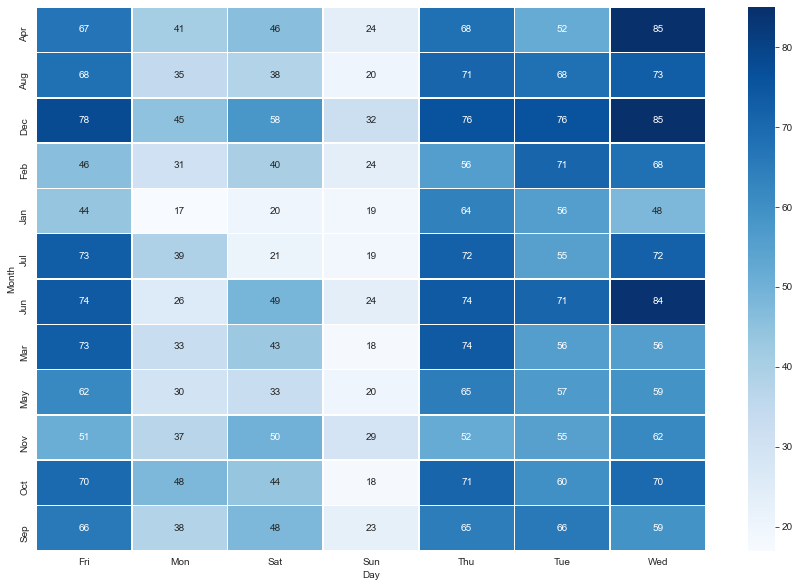

```python
space["Day"] = space["Datum"].map(lambda date : date.split(",")[0]).map(lambda day : day.split(" ")[0])
space["Month"] = space["Datum"].map(lambda date : date.split(",")[0]).map(lambda month : month.split(" ")[1])

x = space.groupby(["Month","Day"])["Launch Number"].count().reset_index()
x = x.pivot("Month","Day","Launch Number").fillna(0)
f, ax = plt.subplots(figsize=(15, 10))
sns.heatmap(x, annot=True, fmt="d" ,linewidths=.5, ax=ax,cmap = "Blues")
```

Which month is most likely suitable for launch?

```python
df['Datum'] = pd.to_datetime(df['Datum'].values)
df['Datum'] = df['Datum'].apply(lambda x : x.replace(tzinfo=None))
df['Datum'] = pd.DatetimeIndex(df['Datum'], freq=None)

ldict = ['Jan', 'Feb', 'Mar', 'Apr', 'May', 'Jun', 'Jul', 'Aug', 'Sept', 'Oct', 'Nov', 'Dec']
data = df.groupby([df.Datum.dt.month, ])['Detail'].count().reset_index()
data.Datum = data.Datum.replace({
    1 : 'Jan', 2 : 'Feb', 3 : 'Mar', 4 : 'Apr', 5 : 'May',
    6 : 'Jun', 7 : 'Jul', 8 : 'Aug', 9 : 'Sept', 10 : 'Oct', 11 : 'Nov', 12 : 'Dec'
})
fig =  px.bar(data, x=data.Datum, y=data.Detail,  text='Detail')
fig.update_layout(
    title_text="Number of Launch per month (all time)",
    title_x = 0.5,
    xaxis_title="Months",
    yaxis_title="Number of Mission",
    template='plotly'
)
fig.show()
```

[interactive chart not shown]

when it comes to rocket launches whether conditions are very important and it changes from country to country. on a whole Maximum number of rockets were launched in december amd minimum number of launches in January

Which day is most likely suitable for launch?

```python
ldict = ['Mon', 'Tue', 'Wed', 'Thu', 'Fri', 'Sat', 'Sun']
data = df.groupby([df.Datum.dt.weekday, ])['Detail'].count().reset_index()
data.Datum = data.Datum.replace({
    0 : 'Mon', 1 : 'Tue', 2 : 'Wed', 3 : 'Thu', 4 : 'Fri',
    5 : 'Sat', 6 : 'Sun'
})
fig =  px.bar(data, x=data.Datum, y=data.Detail,  text='Detail')
fig.update_layout(
    title_text="Number of Launch per day (all time)",
    title_x = 0.5,
    xaxis_title="Days",
    yaxis_title="Number of Mission",
    template='plotly'
)
fig.show()
```

[interactive chart not shown]

It is observed that most of the lauches were on the weekdays and least number of rockets were launched on sundays

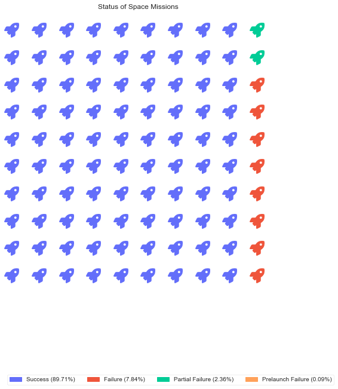

```python
plt.rcParams['figure.figsize'] = (8,12)
data = dict(space_data['Status Mission'].value_counts(normalize = True) * 100)
fig = plt.figure(
    FigureClass=Waffle,
    columns=10,
    values=data,
    colors=('#636EFA', '#EF553B', '#00CC96','#FFA15A'),
    title={'label': 'Status of Space Missions', 'loc': 'center'},
    icons = 'rocket',
    icon_size = 25,
    labels=[f"{k} ({v:.2f}%)" for k, v in data.items()],
    legend={'loc': 'lower left', 'bbox_to_anchor': (0, -0.4), 'ncol': len(data), 'framealpha': 0.3}
)
plt.show()
```

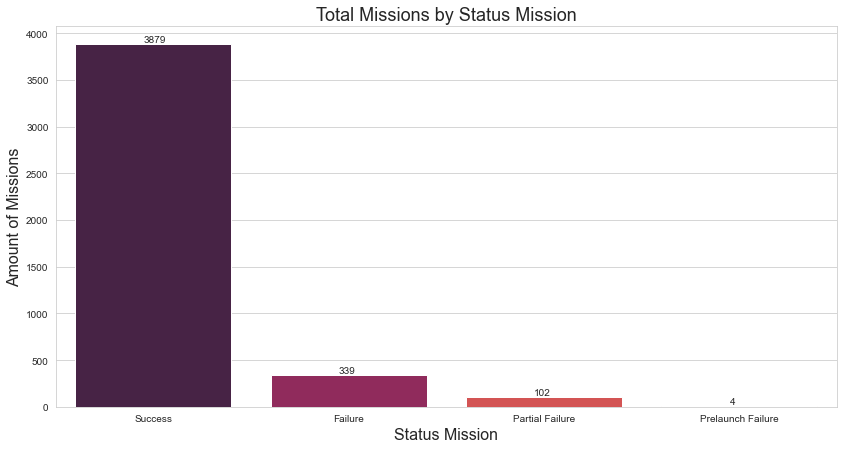

```python
fig = plt.subplots(figsize = (14, 7))
g = sns.barplot(
            x = space_data['Status Mission'].value_counts().index,
            y = space_data['Status Mission'].value_counts().values,
            data = space_data,
            palette = 'rocket')
plt.title('Total Missions by Status Mission', fontdict = {'size':18})
plt.xlabel('Status Mission', fontdict = {'size':16})
plt.ylabel('Amount of Missions', fontdict = {'size':16})
for x in g.patches:
    g.annotate((int(x.get_height())),
    (x.get_x()+0.35,
    x.get_height()+20))
```

Success Mission repartion

```python
status = space["Status Mission"].value_counts().reset_index()
Tab = space.groupby(["Year","Status Mission"])["Launch Number"].count().reset_index()
fig = px.bar(Tab, y='Launch Number', x='Year',color="Status Mission",title='Success distribution by Year',
             color_discrete_sequence = px.colors.qualitative.G10,template = "plotly"
             ,height = 600)
fig.show()
```

[interactive chart not shown]

```python
fig = px.sunburst(space_data,path = ['Status Mission','Country'])
fig.update_layout(margin=dict(l=80, r=80, t=25, b=10),
                  title = { 'text' : '<b>Countries and Mission Status</b>', 'x' : 0.5},
                 font_family = 'Fira Code')
fig.show()
```

[interactive chart not shown]

Status mission by country

```python
x = space.groupby(["Country", "Status Mission"])["Launch Number"].count().reset_index()
x = x[~x.Country.isin(['USA','Russia'])]
fig = px.bar(x, x="Country", y="Launch Number", color="Status Mission",
             color_discrete_sequence = px.colors.qualitative.G10,
             template = "plotly", title = "Mission status of each country",
                  height=600)
fig.show()
```

[interactive chart not shown]

Year by year Mission took place and Mission Status

```python
data = space_data.copy()
data['Date'] = pd.to_datetime(data['Date'], errors='coerce')
data.sort_values('Date',inplace = True)
data['Year'] = data['Date'].dt.year

fig = px.choropleth(data,locations = 'alpha3',animation_frame = 'Year',color = 'Status Mission',title = 'Countries Rocket Mission Status year by year',
                   height = 650)
fig.show()
```

[interactive chart not shown]

```python
sun = space_data.groupby(['Country', 'Company Name', 'Status Mission'])['Datum'].count().reset_index()
sun.columns = [
    'country',
    'company',
    'status',
    'count'
]
fig = px.sunburst(
    sun,
    path=[
        'country',
        'company',
        'status'
    ],
    values='count',
    title='Sunburst chart for all countries',
    width=800,
    height=800
)
fig.show()
```

[interactive chart not shown]

```python
successPerc = space_data[space_data['Status Mission'] == 'Success'].groupby('Company Name')['Status Mission'].count()
for company in successPerc.index:
    successPerc[company] = (successPerc[company] / len(space_data[space_data['Company Name'] == company]))*100
successPerc = successPerc.sort_index()
FailurePerc = space_data[space_data['Status Mission'] == 'Failure'].groupby('Company Name')['Status Mission'].count()
for company in FailurePerc.index:
    FailurePerc[company] = (FailurePerc[company] / len(space_data[space_data['Company Name'] == company]))*100
FailurePerc = FailurePerc.sort_index()
```

```python
trace1 = go.Bar(x = successPerc.index, y = successPerc.values, name = 'Success Rate of Companies',opacity=0.7)
trace2 = go.Bar(x = FailurePerc.index, y = FailurePerc.values, name = 'Failure Rate of Companies',opacity=0.7)
fig = go.Figure([trace1,trace2])
fig.update_layout(template = 'plotly',margin=dict(l=80, r=80, t=25, b=10),
                  title = {'text' : '<b>Success and Failure Rates of Companies</b>', 'x' : 0.5},
                 font_family = 'Fira Code',width = 1000,yaxis_title = '<b>Percentage</b>',xaxis_title = '<b>Companies</b>',
                 legend=dict(
                    yanchor="top",
                    y=0.99,
                    xanchor="left",
                    x=0.01
))

fig.show()
```

[interactive chart not shown]

We measure the Success and Failure Rate of Each company.

Success Rate highlights:

Companies like ASI,Blue Origin,Douglas, IRGC,Khrunichev, OKB-586,Starsem, Yuzhmash and i-Space have a 100% success rate. Failure Rate highlights

Companies like EER, Landspace, OneSpace, Sandia and Virgin Orbit have a 100% failure rate, i.e they haven't had any successful space mission

```python
fig = px.treemap(space_data,path = ['Status Mission','Country','Company Name'])
fig.update_layout(template = 'plotly',margin=dict(l=80, r=80, t=50, b=10),
                  title = { 'text' : '<b>Mission Status,Countries and Companies</b>', 'x' : 0.5},
                 font_family = 'Fira Code')
fig.show()
```

[interactive chart not shown]

Important Thing to Note From the above treemap, I was immediately interested in seeing 'RVSN USSR' having Launch Locations in both Kazakhstan and Russia. After a bit of Googling and looking at the data, I found about the Baikonur Cosmodrome. That ought to explain the reason why we use RVSN USSR entries in both Space Missions launched in Kazakhstan and Russia.

Average cost of a mission per month, as well as the mission status

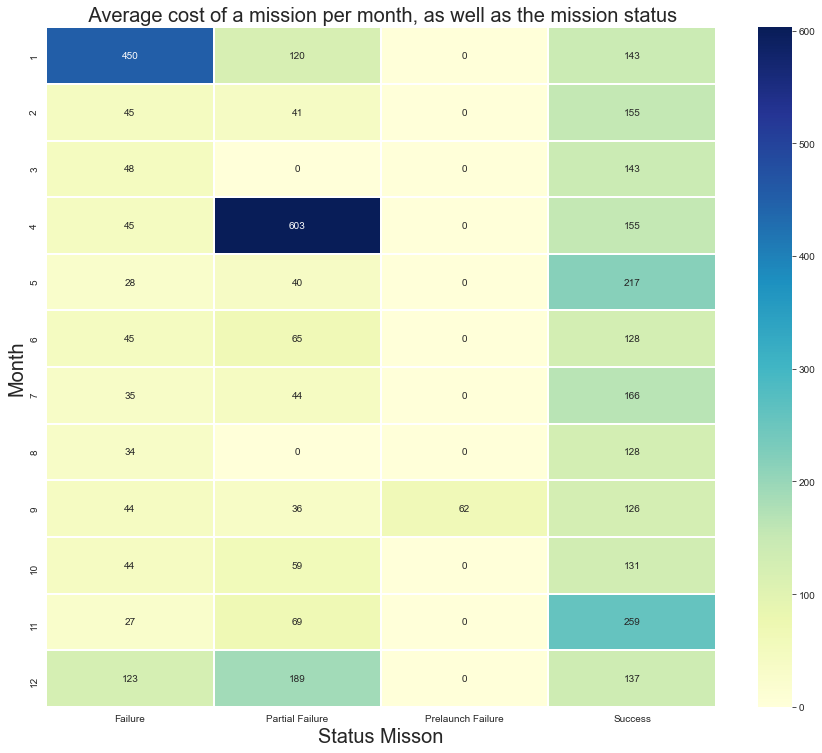

```python
df1 = space_data.copy()
df1.rename(columns = {
    ' Rocket':'Cost_Mission',
    'Datum':'Date_Time'
}, inplace = True)
#df1['Month'] = df1.Date_Time.str.split(' ').str[1]
df1.Cost_Mission = df1.Cost_Mission.str.replace(',', '')
df1.Cost_Mission = df1.Cost_Mission.astype(float)
var = pd.DataFrame()
df_Cost_Mission = df1[df1['Cost_Mission'] > 0]
for b in list(df_Cost_Mission.Month.unique()):
    for v in list(df_Cost_Mission['Status Mission'].unique()):
        z = df_Cost_Mission[(df_Cost_Mission.Month == b) & (df_Cost_Mission['Status Mission'] == v)]['Cost_Mission'].mean()
        var = var.append(pd.DataFrame({'Month':b , 'Status Mission':v , 'avgCost_Mission':z}, index=[0]))
var = var.reset_index(drop = True)
var['avgCost_Mission'].fillna(0,inplace=True)
var['avgCost_Mission'].isnull().value_counts()
var['avgCost_Mission'] = var['avgCost_Mission'].astype(int)
pd.DataFrame(var.head())

tri = var.pivot('Month', 'Status Mission', 'avgCost_Mission')
fig, ax = plt.subplots(figsize=(15, 12.5))
sns.heatmap(tri, linewidths=1, cmap='YlGnBu', annot=True, ax=ax, fmt='d')
ax.set_title(' Average cost of a mission per month, as well as the mission status', fontdict={'size':20})
ax.xaxis.set_label_text('Status Misson',fontdict= {'size':20})
ax.yaxis.set_label_text('Month',fontdict= {'size':20})
plt.show()
```

```python
fail_df = space_data[space_data['Status Mission'] == 'Failure']
plot_map(fail_df, 'Status Mission', 'Number of Fails per country')
```

[interactive chart not shown]

Launch vehicle status

```python
dff = space_data.copy()
```

```python
success = dff[dff['Status Mission']=='Success'].groupby('Rocket Name').count()['Detail'].reset_index()
not_s = dff[dff['Status Mission']!='Success'].groupby('Rocket Name').count()['Detail'].reset_index()
not_s.rename(columns={'Detail':'Fails'},inplace=True)
total = pd.merge(success,not_s,on='Rocket Name').sort_values('Detail',ascending=True)[-50:]
fig = go.Figure()
fig.add_bar(x=total['Detail'],y=total['Rocket Name'],orientation='h',name="Success")
fig.add_bar(x=total['Fails'],y=total['Rocket Name'],orientation='h',name="Failure")

fig.update_layout(barmode="stack",title="Launch vehicle number of success and Failures",xaxis_title="No of Missions",yaxis_title="Launch Vehicle")
fig.show()
```

[interactive chart not shown]

```python
r = space_data.copy()
r = r.groupby(['Country','Status Mission'])['Detail'].count().unstack(fill_value=0).stack().reset_index()
cou = pd.DataFrame({"Country":r['Country'].unique(),"Success":r[r['Status Mission']=="Success"][0].values,
                    "Failure":r[r['Status Mission']=="Failure"][0].values,
                    "Partial Failure":r[r['Status Mission']=="Partial Failure"][0].values,
                    "Prelaunch Failure":r[r['Status Mission']=="Prelaunch Failure"][0].values},
                    columns=["Country","Success","Failure","Partial Failure","Prelaunch Failure"])
```

```python
country_colors=["#01579b","#0277bd","#0288D1","#039BE5","#03A9F4","#29B6F6","#4FC3F7","#81D4FA","#B3E5FC","E1F5FE","E1F5FE"]
country_colors = sum([[i]*2 for i in country_colors],[])

from collections import OrderedDict
from io import StringIO
from math import log, sqrt

import warnings
warnings.filterwarnings('ignore')
from bokeh.plotting import figure, output_file, show
from bokeh.io import output_notebook
from bokeh.resources import INLINE
output_notebook(INLINE)

status_color = OrderedDict([
    ("Success",   "#0d3362"),
    ("Failure", "#c64737"),
    ("Partial Failure", "white"  ),
    ("Prelaunch Failure","black")
])

width = 800
height = 800
inner_radius = 90
outer_radius = 300 - 10

maxr = sqrt(log(1* 1E4))
minr = sqrt(log(1395 * 1E4))
a = (outer_radius - inner_radius) / (minr - maxr)
b = inner_radius - a * maxr

def rad(mic):
    return a * np.sqrt(np.log(mic * 1E4)) + b

big_angle = 2.0 * np.pi / (len(cou)+1)
small_angle = big_angle/7

p = figure(plot_width=width, plot_height=height, title="",
    x_axis_type=None, y_axis_type=None,
    x_range=(-420, 420), y_range=(-420, 420),
    min_border=0, outline_line_color="black",
    background_fill_color="#f0e1d2")

p.xgrid.grid_line_color = None
p.ygrid.grid_line_color = None

# annular wedges
angles = np.pi/2 - big_angle/2 - cou.index.to_series()*big_angle
colors = country_colors
p.annular_wedge(
    0, 0, inner_radius, outer_radius, -big_angle+angles, angles, color=colors,
)
# small wedges
p.annular_wedge(0, 0, inner_radius, rad(cou['Success']),
                -big_angle+angles+7*small_angle, -big_angle+angles+8*small_angle,
                color=status_color['Success'])
p.annular_wedge(0, 0, inner_radius, rad(cou['Failure']),
                -big_angle+angles+5*small_angle, -big_angle+angles+6*small_angle,
                color=status_color['Failure'])
p.annular_wedge(0, 0, inner_radius, rad(cou["Partial Failure"]),
                -big_angle+angles+3*small_angle, -big_angle+angles+4*small_angle,
                color=status_color['Partial Failure'])
p.annular_wedge(0, 0, inner_radius, rad(cou["Prelaunch Failure"]),
                -big_angle+angles+1*small_angle, -big_angle+angles+2*small_angle,
                color=status_color['Prelaunch Failure'])

# circular axes and lables
labels = np.power(10.0, np.arange(1,4))
radii = a * np.sqrt(np.log(labels * 1E4)) + b
p.circle(0, 0, radius=radii, fill_color=None, line_color="#afc1ce")
p.text(0, radii[:], [str(r) for r in labels[:]],
       text_font_size="11px", text_align="center", text_baseline="middle")

# radial axes
p.annular_wedge(0, 0, inner_radius-10, outer_radius+10,
                -big_angle+angles, -big_angle+angles, color="white")

# #  labels
xr = radii[-1]*np.cos(np.array(-big_angle/2+ angles))+0.8
yr = radii[-1]*np.sin(np.array(-big_angle/2 + angles))+0.8
label_angle=np.array(-big_angle/2+angles)
label_angle[label_angle < -np.pi/2] += np.pi
p.text(xr, yr, cou.Country, angle=label_angle,
       text_font_size="11px", text_align="center", text_baseline="middle")
p.rect([-40, -40, -40,-40], [36, 18,0,-18], width=20, height=13,
       color=list(status_color.values()))
p.text([-15, -15,-15, -15], [36, 18,0,-18], text=list(status_color),
       text_font_size="10px", text_align="left", text_baseline="middle")

show(p)
```

[output not shown]

Companies with Successful Missions

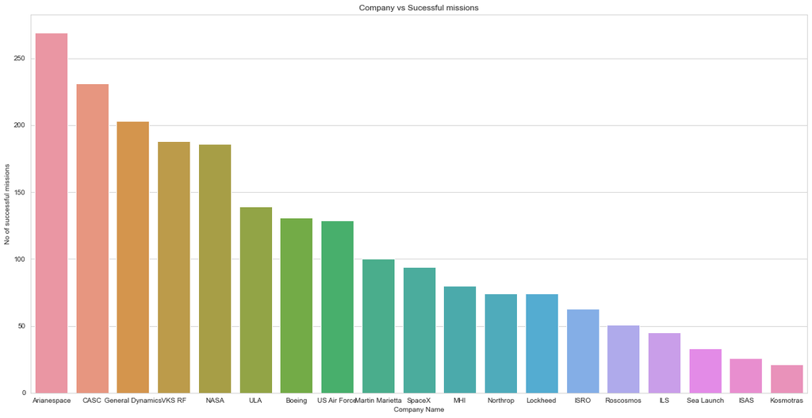

```python
plt.figure(figsize=(20,10))
cmp = df.groupby(['Company Name','Status Mission']).count()['Detail'].reset_index()
cmp = cmp[cmp['Status Mission']=="Success"].sort_values('Detail',ascending=False)
sns.barplot(x='Company Name',y='Detail',data=cmp[1:20])
plt.ylabel('No of successful missions')
t=plt.title('Company vs Sucessful missions')
```

Companies with UnSuccessful Missions

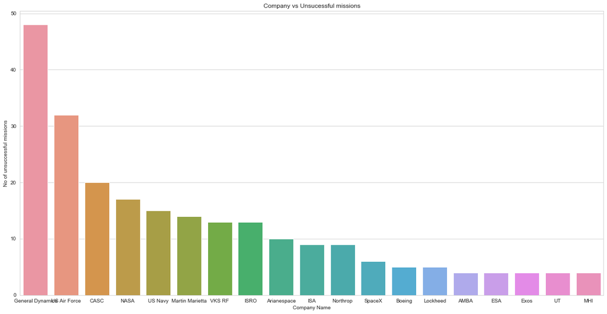

```python
plt.figure(figsize=(20,10))
cmp = df[df['Status Mission']!="Success"].groupby('Company Name').count().sort_values('Detail',ascending=False).reset_index()
sns.barplot(x='Company Name',y='Detail',data=cmp[1:20])
plt.ylabel('No of unsuccessful missions')
t=plt.title('Company vs Unsucessful missions')
```

```python
df5 = space_data.copy()
df5['Date'] = df5['Datum'].apply(lambda x:" ".join(x.split()[:4]))
df5['Date'] = df5['Datum'].apply(lambda x:" ".join(x.split()[:4]))
df5['Date'] = df5['Date'].apply(pd.to_datetime)
df5.set_index('Date',inplace=True)
v = df5.reset_index().groupby(['Date','Status Mission']).count()['Detail'].reset_index()
succ = v[v['Status Mission']!="Success"].set_index('Date').resample('M').count().reset_index()
unsuccess = go.Scatter(x=succ.Date,y=succ['Detail'],yaxis='y2',name='Unucessful Launches')
unsucc = v[v['Status Mission']=="Success"].set_index('Date').resample('M').count().reset_index()
success = go.Scatter(x=unsucc.Date,y=unsucc['Detail'],name='Successful Launches')


layout = go.Layout(height=450, width=1000,
                   title='Successful and Unsuccessful Launches Plot',
                   xaxis=dict(title='Date'),
                   yaxis=dict(title='Successful', color='blue'),
                   yaxis2=dict(title='Unsuccessful', color='red',
                               overlaying='y', side='right')
                   )
fig = go.Figure(data=[success, unsuccess],layout=layout)
fig.update_xaxes(rangeslider_visible=True)
fig.show()
```

[interactive chart not shown]

Launches until first success

```python
date=[]
time=[]
year=[]
for i in range(0,space_data.shape[0]):
    str=space_data['Datum'].iloc[i]
    day=str[:3]
    mm=str[4:7]
    dd=str[8:10]
    aaaa=str[12:16]
    hh_mm=str[17:22]
    str = dd+'/'+mm+'/'+aaaa
    date_object = datetime.strptime(str, '%d/%b/%Y')
    date.append(date_object)
    year.append(aaaa)

Space_data = space_data.copy()
Space_data['Date'] = date
Space_data['Year'] = year
Space_data['Year']=pd.to_numeric(Space_data.Year)
```

```
No handles with labels found to put in legend.
```

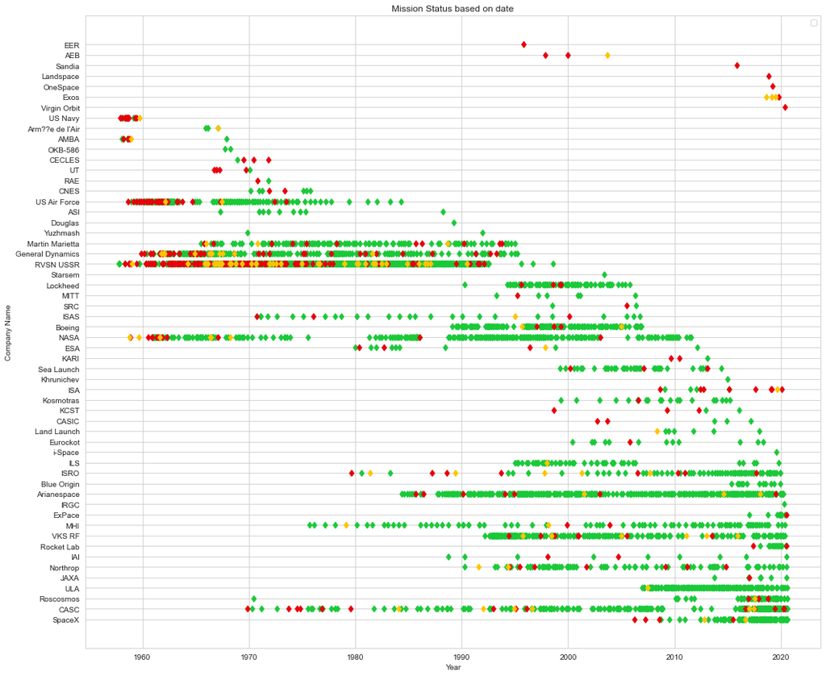

```python
mask_status_s=Space_data['Status Mission']=='Success'
mask_status_f=Space_data['Status Mission']=='Failure'
mask_status_prf=Space_data['Status Mission']=='Prelaunch Failure'
mask_status_pf=Space_data['Status Mission']=='Partial Failure'

plt.figure()
plt.subplots(figsize=(17,15))
plt.plot(Space_data['Date'][mask_status_s],Space_data['Company Name'][mask_status_s],'gd',Space_data['Date'][mask_status_f],Space_data['Company Name'][mask_status_f],'rd',Space_data['Date'][mask_status_prf|mask_status_pf],Space_data['Company Name'][mask_status_prf|mask_status_pf],'yd')
plt.title("Mission Status based on date")
plt.xlabel("Year")
plt.ylabel("Company Name")
plt.legend(loc="best");
```

With this plot we can conclude that the failed missions are more important at the beggining of the Space Race (the earliest dates of the history of space missions), than at the beggining of the individual companies.

There are more mutual information and more experience as time advances and the different companies take proffit of it. This is a general tendence and it's not true for every company, as we can see for ISA.

```python
mask_status_ISA=Space_data['Company Name']=='ISA'
Space_data[mask_status_ISA]
```

|  | Unnamed: 0 | Company Name | Location | Datum | Detail | Status Rocket | Rocket | Status Mission | Country | alpha3 | ... | Days | Date | Year | Month | Date_Time | weekday | Region | States | center | Rocket Name |
| --- | --- | --- | --- | --- | --- | --- | --- | --- | --- | --- | --- | --- | --- | --- | --- | --- | --- | --- | --- | --- | --- |
| 52 | 52 | ISA | Imam Khomeini Spaceport, Semnan Space Center, ... | Sun Feb 09, 2020 15:48 UTC | Simorgh \| Zafar 1 | StatusActive | NaN | Failure | Iran | IRN | ... | Sunday | 2020-02-09 | 2020 | 2 | 2020-02-09 15:48:00 | 6 | Semnan Space Center, Iran | Semnan Space Center | Semnan Space Center | Simorgh |
| 106 | 106 | ISA | Imam Khomeini Spaceport, Semnan Space Center, ... | Thu Aug 29, 2019 | Safir-1B+ \| Nahid-1 | StatusActive | NaN | Prelaunch Failure | Iran | IRN | ... | Thursday | 2019-08-29 | 2019 | 8 | 2019-08-29 00:00:00 | 3 | Semnan Space Center, Iran | Semnan Space Center | Semnan Space Center | Safir-1B+ |
| 163 | 163 | ISA | Imam Khomeini Spaceport, Semnan Space Center, ... | Tue Feb 05, 2019 | Safir-1B+ \| Dousti | StatusActive | NaN | Failure | Iran | IRN | ... | Tuesday | 2019-02-05 | 2019 | 2 | 2019-02-05 00:00:00 | 1 | Semnan Space Center, Iran | Semnan Space Center | Semnan Space Center | Safir-1B+ |
| 169 | 169 | ISA | Imam Khomeini Spaceport, Semnan Space Center, ... | Tue Jan 15, 2019 00:30 UTC | Simorgh \| Payam-e Amirkabir | StatusActive | NaN | Failure | Iran | IRN | ... | Tuesday | 2019-01-15 | 2019 | 1 | 2019-01-15 00:30:00 | 1 | Semnan Space Center, Iran | Semnan Space Center | Semnan Space Center | Simorgh |
| 335 | 335 | ISA | Imam Khomeini Spaceport, Semnan Space Center, ... | Thu Jul 27, 2017 | Simorgh \| Test Flight | StatusActive | NaN | Failure | Iran | IRN | ... | Thursday | 2017-07-27 | 2017 | 7 | 2017-07-27 00:00:00 | 3 | Semnan Space Center, Iran | Semnan Space Center | Semnan Space Center | Simorgh |
| 515 | 515 | ISA | Imam Khomeini Spaceport, Semnan Space Center, ... | Tue Feb 17, 2015 | Safir-1B+ \| Unknown Payload | StatusActive | NaN | Failure | Iran | IRN | ... | Tuesday | 2015-02-17 | 2015 | 2 | 2015-02-17 00:00:00 | 1 | Semnan Space Center, Iran | Semnan Space Center | Semnan Space Center | Safir-1B+ |
| 518 | 518 | ISA | Imam Khomeini Spaceport, Semnan Space Center, ... | Mon Feb 02, 2015 | Safir-1B+ \| Fajr | StatusActive | NaN | Success | Iran | IRN | ... | Monday | 2015-02-02 | 2015 | 2 | 2015-02-02 00:00:00 | 0 | Semnan Space Center, Iran | Semnan Space Center | Semnan Space Center | Safir-1B+ |
| 632 | 632 | ISA | Imam Khomeini Spaceport, Semnan Space Center, ... | Sat Sep 22, 2012 | Safir-1B+ \| Unknown Payload | StatusActive | NaN | Failure | Iran | IRN | ... | Saturday | 2012-09-22 | 2012 | 9 | 2012-09-22 00:00:00 | 5 | Semnan Space Center, Iran | Semnan Space Center | Semnan Space Center | Safir-1B+ |
| 646 | 646 | ISA | Imam Khomeini Spaceport, Semnan Space Center, ... | Wed May 23, 2012 | Safir-1B+ \| Unknown Payload | StatusActive | NaN | Failure | Iran | IRN | ... | Wednesday | 2012-05-23 | 2012 | 5 | 2012-05-23 00:00:00 | 2 | Semnan Space Center, Iran | Semnan Space Center | Semnan Space Center | Safir-1B+ |
| 658 | 658 | ISA | Imam Khomeini Spaceport, Semnan Space Center, ... | Fri Feb 03, 2012 | Safir-1B \| Navid | StatusRetired | NaN | Success | Iran | IRN | ... | Friday | 2012-02-03 | 2012 | 2 | 2012-02-03 00:00:00 | 4 | Semnan Space Center, Iran | Semnan Space Center | Semnan Space Center | Safir-1B |
| 684 | 684 | ISA | Imam Khomeini Spaceport, Semnan Space Center, ... | Wed Jun 15, 2011 | Safir-1A \| Rasad 1 | StatusRetired | NaN | Success | Iran | IRN | ... | Wednesday | 2011-06-15 | 2011 | 6 | 2011-06-15 00:00:00 | 2 | Semnan Space Center, Iran | Semnan Space Center | Semnan Space Center | Safir-1A |
| 785 | 785 | ISA | Imam Khomeini Spaceport, Semnan Space Center, ... | Mon Feb 02, 2009 | Safir-1 \| Omid | StatusRetired | NaN | Success | Iran | IRN | ... | Monday | 2009-02-02 | 2009 | 2 | 2009-02-02 00:00:00 | 0 | Semnan Space Center, Iran | Semnan Space Center | Semnan Space Center | Safir-1 |
| 806 | 806 | ISA | Imam Khomeini Spaceport, Semnan Space Center, ... | Sun Aug 17, 2008 | Safir-1 \| Unknown Payload | StatusRetired | NaN | Failure | Iran | IRN | ... | Sunday | 2008-08-17 | 2008 | 8 | 2008-08-17 00:00:00 | 6 | Semnan Space Center, Iran | Semnan Space Center | Semnan Space Center | Safir-1 |

13 rows × 23 columns

```python
mask_success = Space_data['Status Mission']=='Success'
Space_data_success = Space_data.loc[mask_success]
mask_first = (Space_data_success['Date']).groupby([Space_data_success['Company Name']]).idxmin()
Space_data_first = Space_data_success.loc[mask_first]

Space_data[Space_data['Company Name']=='ExPace']
```

|  | Unnamed: 0 | Company Name | Location | Datum | Detail | Status Rocket | Rocket | Status Mission | Country | alpha3 | ... | Days | Date | Year | Month | Date_Time | weekday | Region | States | center | Rocket Name |
| --- | --- | --- | --- | --- | --- | --- | --- | --- | --- | --- | --- | --- | --- | --- | --- | --- | --- | --- | --- | --- | --- |
| 11 | 11 | ExPace | Site 95, Jiuquan Satellite Launch Center, China | Fri Jul 10, 2020 04:17 UTC | Kuaizhou 11 \| Jilin-1 02E, CentiSpace-1 S2 | StatusActive | 28.3 | Failure | China | CHN | ... | Friday | 2020-07-10 | 2020 | 7 | 2020-07-10 04:17:00 | 4 | Jiuquan Satellite Launch Center, China | Jiuquan Satellite Launch Center | Jiuquan Satellite Launch Center | Kuaizhou 11 |
| 31 | 31 | ExPace | Site 95, Jiuquan Satellite Launch Center, China | Tue May 12, 2020 01:16 UTC | Kuaizhou 1A \| Xingyun-2 01 (Wuhan) & 02 | StatusActive | NaN | Success | China | CHN | ... | Tuesday | 2020-05-12 | 2020 | 5 | 2020-05-12 01:16:00 | 1 | Jiuquan Satellite Launch Center, China | Jiuquan Satellite Launch Center | Jiuquan Satellite Launch Center | Kuaizhou 1A |
| 59 | 59 | ExPace | Site 95, Jiuquan Satellite Launch Center, China | Thu Jan 16, 2020 03:02 UTC | Kuaizhou 1A \| Yinhe-1 | StatusActive | NaN | Success | China | CHN | ... | Thursday | 2020-01-16 | 2020 | 1 | 2020-01-16 03:02:00 | 3 | Jiuquan Satellite Launch Center, China | Jiuquan Satellite Launch Center | Jiuquan Satellite Launch Center | Kuaizhou 1A |
| 74 | 74 | ExPace | Site 9401 (SLS-2), Jiuquan Satellite Launch Ce... | Sat Dec 07, 2019 08:52 UTC | Kuaizhou 1A \| HEAD-2A/B / SpaceTY 16/17 / Tian... | StatusActive | NaN | Success | China | CHN | ... | Saturday | 2019-12-07 | 2019 | 12 | 2019-12-07 08:52:00 | 5 | Jiuquan Satellite Launch Center, China | Jiuquan Satellite Launch Center | Jiuquan Satellite Launch Center | Kuaizhou 1A |
| 75 | 75 | ExPace | Taiyuan Satellite Launch Center, China | Sat Dec 07, 2019 02:55 UTC | Kuaizhou 1A \| Jilin-1 Gaofen-02B | StatusActive | NaN | Success | China | CHN | ... | Saturday | 2019-12-07 | 2019 | 12 | 2019-12-07 02:55:00 | 5 | Taiyuan Satellite Launch Center, China | Taiyuan Satellite Launch Center | China | Kuaizhou 1A |
| 84 | 84 | ExPace | Site 95, Jiuquan Satellite Launch Center, China | Sun Nov 17, 2019 10:00 UTC | Kuaizhou 1A \| KL-Alpha A, KL-Alpha B | StatusActive | NaN | Success | China | CHN | ... | Sunday | 2019-11-17 | 2019 | 11 | 2019-11-17 10:00:00 | 6 | Jiuquan Satellite Launch Center, China | Jiuquan Satellite Launch Center | Jiuquan Satellite Launch Center | Kuaizhou 1A |
| 86 | 86 | ExPace | Site 95, Jiuquan Satellite Launch Center, China | Wed Nov 13, 2019 03:40 UTC | Kuaizhou 1A \| Jilin 1-02A | StatusActive | NaN | Success | China | CHN | ... | Wednesday | 2019-11-13 | 2019 | 11 | 2019-11-13 03:40:00 | 2 | Jiuquan Satellite Launch Center, China | Jiuquan Satellite Launch Center | Jiuquan Satellite Launch Center | Kuaizhou 1A |
| 104 | 104 | ExPace | Site 95, Jiuquan Satellite Launch Center, China | Fri Aug 30, 2019 23:41 UTC | Kuaizhou 1A \| KX-09 & Others | StatusActive | NaN | Success | China | CHN | ... | Friday | 2019-08-30 | 2019 | 8 | 2019-08-30 23:41:00 | 4 | Jiuquan Satellite Launch Center, China | Jiuquan Satellite Launch Center | Jiuquan Satellite Launch Center | Kuaizhou 1A |
| 211 | 211 | ExPace | Site 95, Jiuquan Satellite Launch Center, China | Sat Sep 29, 2018 04:13 UTC | Kuaizhou 1A \| CentiSpace-1 S1 | StatusActive | NaN | Success | China | CHN | ... | Saturday | 2018-09-29 | 2018 | 9 | 2018-09-29 04:13:00 | 5 | Jiuquan Satellite Launch Center, China | Jiuquan Satellite Launch Center | Jiuquan Satellite Launch Center | Kuaizhou 1A |
| 379 | 379 | ExPace | Site 95, Jiuquan Satellite Launch Center, China | Mon Jan 09, 2017 04:11 UTC | Kuaizhou 1A \| Jilin-1 03, Caton-1 & Xingyun Sh... | StatusActive | NaN | Success | China | CHN | ... | Monday | 2017-01-09 | 2017 | 1 | 2017-01-09 04:11:00 | 0 | Jiuquan Satellite Launch Center, China | Jiuquan Satellite Launch Center | Jiuquan Satellite Launch Center | Kuaizhou 1A |

10 rows × 23 columns

```python
Space_data_first[Space_data['Company Name']=='ExPace']
```

|  | Unnamed: 0 | Company Name | Location | Datum | Detail | Status Rocket | Rocket | Status Mission | Country | alpha3 | ... | Days | Date | Year | Month | Date_Time | weekday | Region | States | center | Rocket Name |
| --- | --- | --- | --- | --- | --- | --- | --- | --- | --- | --- | --- | --- | --- | --- | --- | --- | --- | --- | --- | --- | --- |
| 379 | 379 | ExPace | Site 95, Jiuquan Satellite Launch Center, China | Mon Jan 09, 2017 04:11 UTC | Kuaizhou 1A \| Jilin-1 03, Caton-1 & Xingyun Sh... | StatusActive | NaN | Success | China | CHN | ... | Monday | 2017-01-09 | 2017 | 1 | 2017-01-09 04:11:00 | 0 | Jiuquan Satellite Launch Center, China | Jiuquan Satellite Launch Center | Jiuquan Satellite Launch Center | Kuaizhou 1A |

1 rows × 23 columns

```python
prev=[]

for i in range(0,Space_data.shape[0]):
    Company_ns=Space_data['Company Name'].iloc[i]
    Date_ns=Space_data['Date'].iloc[i]
    Status_ns=Space_data['Status Mission'].iloc[i]

    if Status_ns!='Success':
        one_first=0
        for j in range(0,Space_data_first.shape[0]):
            Company_fs=Space_data_first['Company Name'].iloc[j]
            Status_fs=Space_data_first['Status Mission'].iloc[j]
            Date_fs=Space_data_first['Date'].iloc[j]
            if Company_ns==Company_fs:
                one_first+=1
                if Date_ns<Date_fs:
                    prev.append(i)
                break
        if one_first==0:
            # it means that this company hasn't no Successful Mission
            prev.append(i)

fail_columns = ['Company Name','Detail','Date','Year','Status Mission']
Space_data_fail_prev=Space_data.loc[prev,fail_columns]#.sort_values('Year').sort_values('Company Name')
Space_data_fail_prev.head()
```

|  | Company Name | Detail | Date | Year | Status Mission |
| --- | --- | --- | --- | --- | --- |
| 27 | Virgin Orbit | LauncherOne \| Demo Flight | 2020-05-25 | 2020 | Failure |
| 91 | Exos | SARGE \| Launch 4 | 2019-10-26 | 2019 | Failure |
| 127 | Exos | SARGE \| Launch 3 | 2019-06-29 | 2019 | Partial Failure |
| 152 | OneSpace | OS-M1 \| Lingque-1B | 2019-03-27 | 2019 | Failure |
| 157 | Exos | SARGE \| Launch 2 | 2019-03-02 | 2019 | Partial Failure |

```
No handles with labels found to put in legend.
```

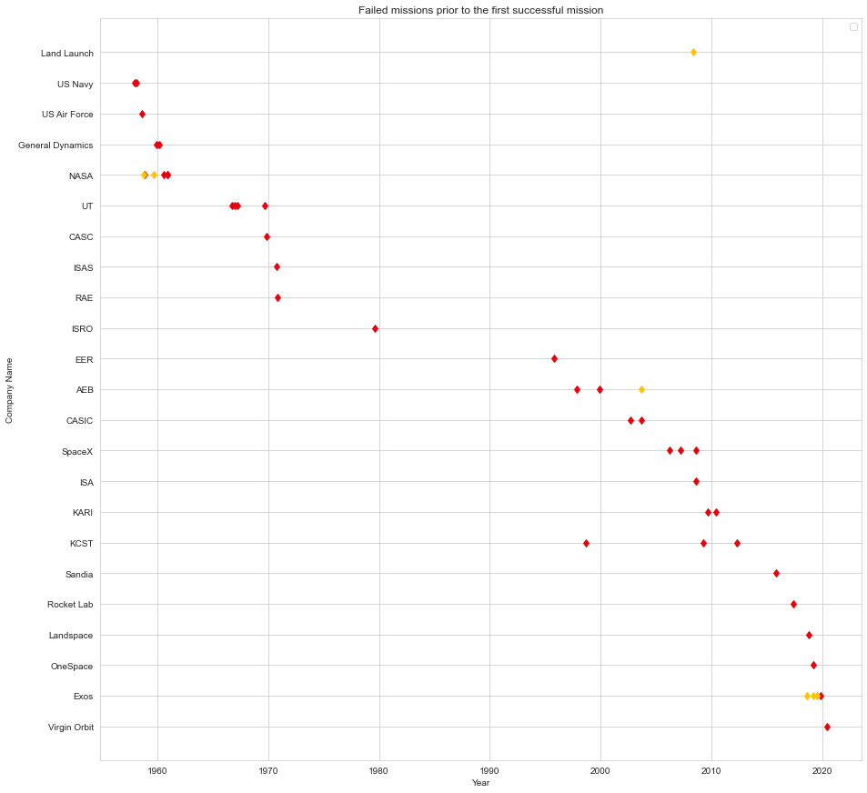

```python
plt.figure()
plt.subplots(figsize=(15,15))
plt.plot(Space_data_fail_prev['Date'][mask_status_s],Space_data_fail_prev['Company Name'][mask_status_s],'gd',Space_data_fail_prev['Date'][mask_status_f],Space_data_fail_prev['Company Name'][mask_status_f],'rd',Space_data_fail_prev['Date'][mask_status_prf|mask_status_pf],Space_data_fail_prev['Company Name'][mask_status_prf|mask_status_pf],'yd')
plt.title("Failed missions prior to the first successful mission")
plt.xlabel("Year")
plt.ylabel("Company Name")
plt.legend(loc="best");
```

Status of the Rocket

```python
status = df['Status Rocket'].value_counts()
fig = make_subplots(rows=1, cols=2, specs=[[{"type": "xy"}, {"type": "domain"}]])
fig.add_trace(go.Bar( x=status.keys(), y=status.values, text=status.values.tolist(), textposition='auto',marker_color='#003786',name='Status'), row=1, col=1)
fig.add_trace(go.Pie(labels=status.keys(),values=status.values,textposition='inside', textinfo='percent+label',marker={'colors':['rgb(178,24,43)','rgb(253,219,199)']}), row=1, col=2)
fig.update_layout(title_text='Status of Rockets', font_size=10, autosize=False, width=1000, height=600)
fig.show()
```

[interactive chart not shown]

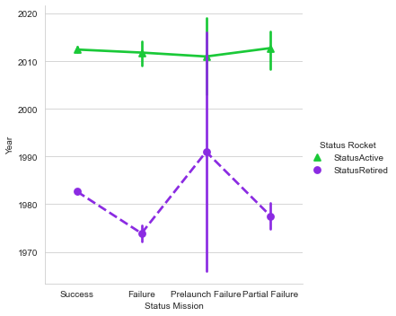

```python
sns.catplot(x="Status Mission", y="Year", hue="Status Rocket",
            palette={"StatusActive": "g", "StatusRetired": "m"},
            markers=["^", "o"], linestyles=["-", "--"],
            kind="point", data=space_data)
```

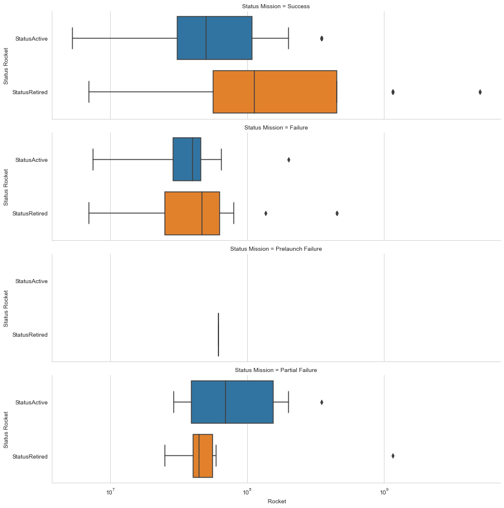

```python
g = sns.catplot(x=" Rocket", y="Status Rocket", row="Status Mission",
                kind="box", orient="h", height=3, aspect=4,
                data=df3)
g.set(xscale="log")
```

```python
top_20 = companies[1:40]
cmp = df.groupby(['Company Name','Status Rocket']).count()['Detail'].reset_index()
cmp = cmp[cmp['Company Name'].isin(top_20['Company Name'])]
active = cmp[cmp['Status Rocket']=="StatusActive"].sort_values('Detail')
retired = cmp[cmp['Status Rocket']!="StatusActive"]
fig = go.Figure()
fig.add_bar(y=active['Detail'],x=active['Company Name'],name='Status Active')
fig.add_bar(y=retired['Detail'],x=retired['Company Name'],name='Status Retired')
fig.update_layout(barmode="stack",title="Comapnies and Mission Status",yaxis_title="No of Missions")
fig.show()
```

[interactive chart not shown]

```python
x = space.groupby(["Country","Status Rocket"])["Launch Number"].count().reset_index().rename(columns = {"Launch Number" : "Count"})
fig = px.sunburst(x,
                  path=['Status Rocket','Country'],
                  values='Count',
                  color_discrete_sequence = px.colors.qualitative.Set1,
                  template = "plotly",title = "Rocket status for each country",
                  width=1000,height=600)
fig.show()
```

[interactive chart not shown]

Status evolution In this section we analyse the Status Rocket for each country

[figure not shown]

```
The oldest and still active satellite has been launched in 1982 by China from Site 138 (LA-2B), Jiuquan Satellite Launch Center, China
```

```python
df6 = space_data.copy()
df6['Year'] =  df6['Year'].astype('int64')
statut_evol=df6.groupby(['Year', 'Status Rocket']).count()['Country'].rename('count').unstack()
statut_evol.plot(kind='bar',stacked=True)
plt.locator_params(nbins=20)
plt.show()

oldest = df6.iloc[df6[df6['Status Rocket'] == 'StatusActive']['Year'].idxmin(axis=0)]
print(f'The oldest and still active satellite has been launched in {oldest["Year"]} '
      f'by {oldest["Country"]} from {oldest["Location"]}')
```

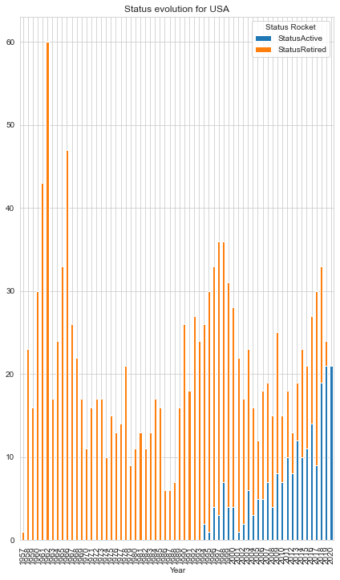

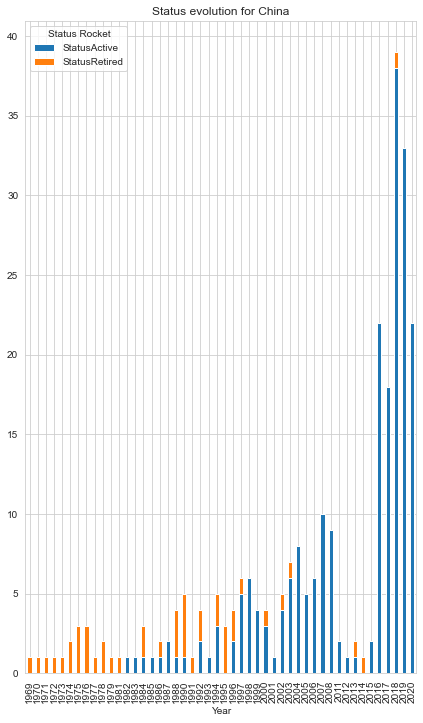

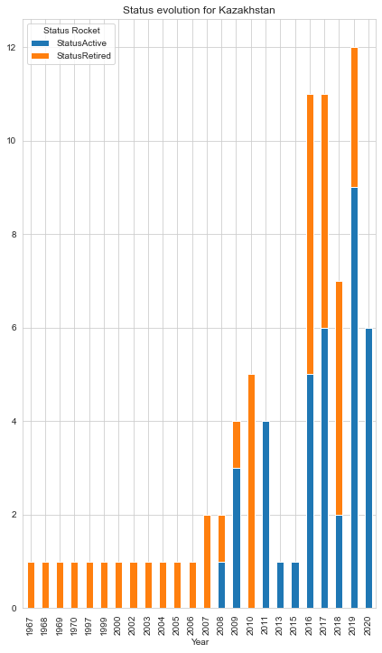

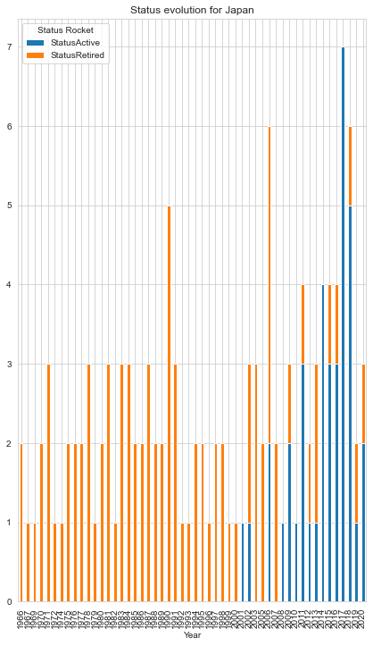

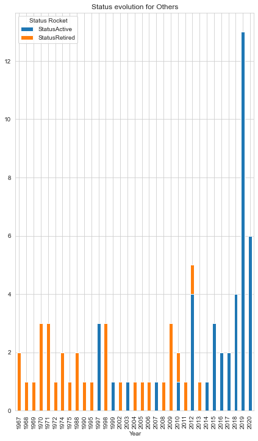

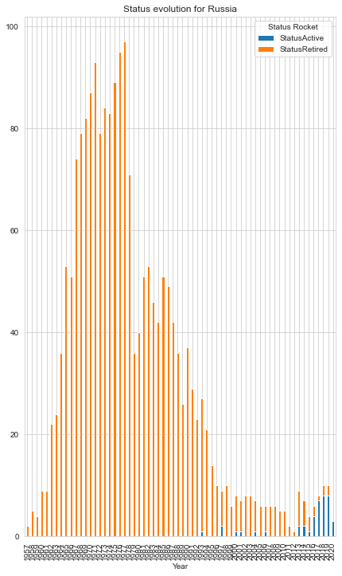

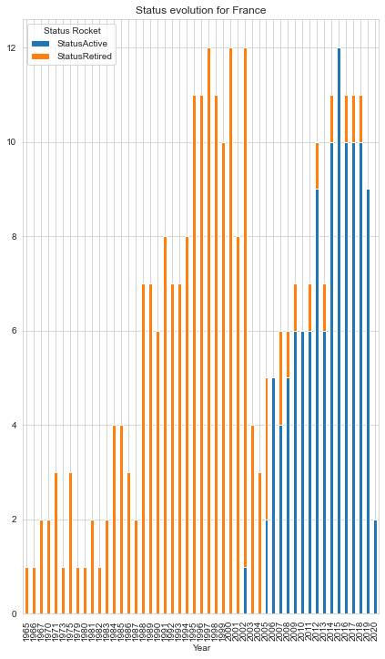

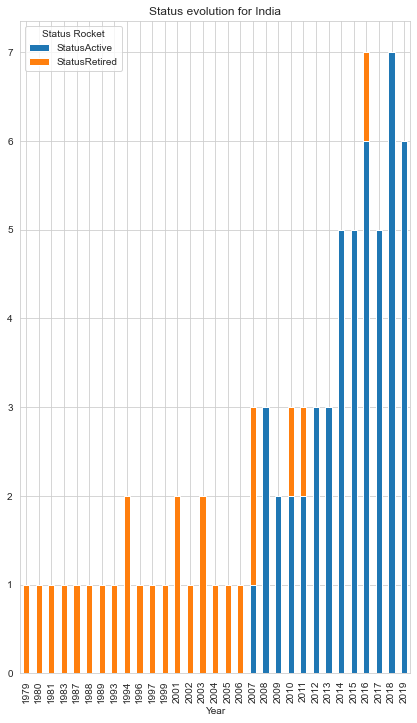

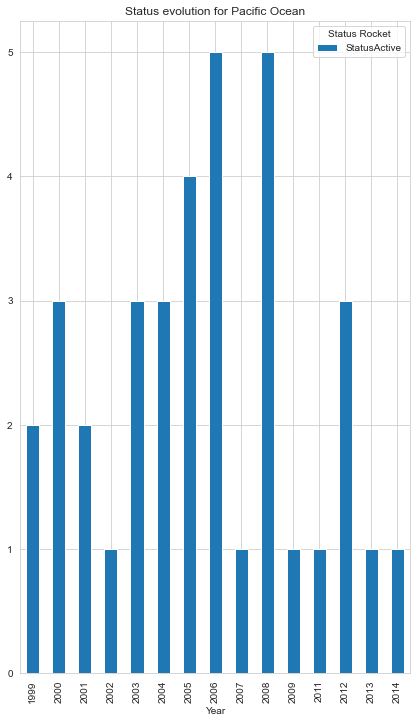

```python
df_countries=space_data.groupby('Country').count().sort_values('Location', ascending=False)
eight_first_country=df_countries.head(8).index
df_countries = space_data.copy()
df_countries['Country'] = space_data['Country'].apply(lambda a : a if a in eight_first_country else 'Others')

dict_display = []
for country in df_countries['Country'].unique():
    statut_evol=df_countries[df_countries['Country']==country].groupby(['Year', 'Status Rocket']).count()['Country'].rename('count').unstack()
    statut_evol.plot(kind='bar',stacked=True,title='Status evolution for '+country)
    plt.show()

    sum = statut_evol.sum(axis=0)
    if len(sum)==2:
        dict_display.append([country, (sum[0]/(sum[0]+sum[1])).round(3)*100, sum[0]])
```

```python
for a in dict_display:
    print(f'{a[0]} has {a[2]} missions still active, that represented {a[1].round(1)}% of its total missions')
```

```
USA has 208.0 missions still active, that represented 15.5% of its total missions
China has 223.0 missions still active, that represented 83.2% of its total missions
Kazakhstan has 38.0 missions still active, that represented 48.7% of its total missions
Japan has 38.0 missions still active, that represented 30.2% of its total missions
Others has 42.0 missions still active, that represented 56.0% of its total missions
Russia has 42.0 missions still active, that represented 2.1% of its total missions
France has 113.0 missions still active, that represented 37.3% of its total missions
India has 50.0 missions still active, that represented 65.8% of its total missions
```

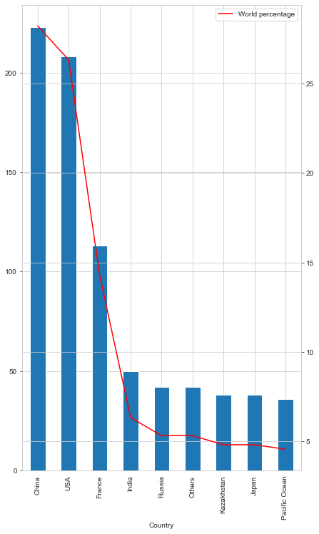

```python
fig= plt.figure()
statut_evol=df_countries[df_countries['Status Rocket']=='StatusActive'].groupby(['Country']).count()['Datum'].rename('count')
statut_evol.sort_values(ascending=False, inplace=True)
ax1=statut_evol.plot(kind='bar')
sum = statut_evol.sum(axis=0)
statut_evol = statut_evol*100/sum
ax2=ax1.twinx()
ax2.plot(statut_evol, color='red', label='World percentage')
plt.legend()
plt.show()
```

treemap visualization of active missions

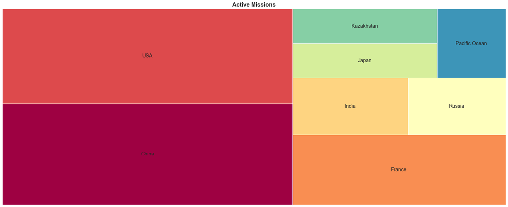

```python
active_missions = space_data[space_data['Status Rocket'] == 'StatusActive']['Country'].value_counts().head(8)
values = active_missions.values[:]
index = active_missions.index[:]
colors = [plt.cm.Spectral(i/float(len(index))) for i in range(len(index))]

plt.figure(figsize=(25,10))
squarify.plot(label=index, sizes=values, color=colors, text_kwargs={'fontsize':14})
plt.title('Active Missions', weight='bold', fontsize=16)
plt.axis('off')

plt.show()
```

Analyzing the effect of Mission Cost

```python
df2 = space_data.copy()
df2[' Rocket'] = df2[' Rocket'].str.replace(r',', '').astype('float64')
df2[' Rocket'] = df2[' Rocket'].fillna(0)

costDict = dict(df2[df2[' Rocket'] > 0].groupby('Year')[' Rocket'].mean())
fig = go.Figure(go.Scatter(x = list(costDict.keys()), y = list(costDict.values()), yaxis = 'y2',mode = 'lines',showlegend=False,name = 'Average Mission Cost Over the years'))
fig.update_layout(template = 'plotly',margin=dict(l=80, r=80, t=50, b=10),
                  title = { 'text' : '<b>Average Mission Cost Over the years</b>', 'x' : 0.5},
                 font_family = 'Fira Code',
                 yaxis_title = '<b>Cost of Mission in Million Dollars</b>',xaxis_title = '<b>Year of Launch</b>',)
fig.show()
```

[interactive chart not shown]

```python
df3 = space_data.copy()

df3[' Rocket'] = df3[' Rocket'].str.replace(r',', '').astype('float64')
df3[' Rocket'] = df3[' Rocket'] * 1000000
```

Total money spent on missions

```python
data = df3.groupby(['Company Name'])[' Rocket'].sum().reset_index()
data = data[data[' Rocket'] > 0]

data.columns = [
    'company',
    'money'
]

fig = px.bar(
    data,
    x='company',
    y="money",
    orientation='v',
    title='Total money spent on missions',
    width=1000,
    height=800,
    template = "plotly"
)
fig.show()
```

[interactive chart not shown]

Average money per one launch

```python
money = df3.groupby(['Company Name'])[' Rocket'].sum()
starts = df['Company Name'].value_counts().reset_index()

starts.columns = [
    'Company Name',
    'count'
]

av_money_df = pd.merge(money, starts, on='Company Name')
av_money_df['avg'] = av_money_df[' Rocket'] / av_money_df['count']
av_money_df = av_money_df[av_money_df['avg']>0]
av_money_df = av_money_df.reset_index()

fig = px.bar(
    av_money_df,
    x='Company Name',
    y="avg",
    orientation='v',
    title='Average money per one launch',
    width=1000,
    height=800
)

fig.show()
```

[interactive chart not shown]

```python
df4 = space_data.copy()
df4[' Rocket'] = df4[' Rocket'].str.replace(r',', '').astype('float64')
```

Average Mission Cost Over the years For Various Countries

```python
fig = px.scatter(df4[df4[' Rocket'].between(1,4999)],x = 'Year', y = 'Country', color = 'Status Mission',size = ' Rocket', size_max=30)
fig.update_layout(template = 'plotly',margin=dict(l=80, r=80, t=50, b=10),
                  title = { 'text' : '<b>Average Mission Cost Over the years For Various Countries</b>', 'x' : 0.5},
                 font_family = 'Fira Code')
fig.show()
```

[interactive chart not shown]

Average Mission Cost Over the years For Various Companies

```python
fig = px.scatter(df4[df4[' Rocket'].between(1,4999)],x = 'Year', y = 'Company Name',color = 'Status Mission',size = ' Rocket',size_max = 30)
fig.update_layout(template = 'plotly',margin=dict(l=80, r=80, t=50, b=10),
                  title = { 'text' : '<b>Average Mission Cost Over the years For Various Companies</b>', 'x' : 0.5},
                 font_family = 'Fira Code',height = 650)
fig.show()
```

[interactive chart not shown]

```python
data_space = pd.read_csv("C:/Users/saumy/Desktop/Space_final2.csv")
```

```python
fig = px.line(data_space, x='Dates', y='Cost of Mission (in million USD)', title='Time Series with Range Slider and Selectors')
fig.update_xaxes(
    rangeslider_visible=True,
    rangeselector=dict(
        buttons=list([
            dict(count=1, label="1m", step="month", stepmode="backward"),
            dict(count=6, label="6m", step="month", stepmode="backward"),
            dict(count=1, label="YTD", step="year", stepmode="todate"),
            dict(count=1, label="1y", step="year", stepmode="backward"),
            dict(step="all")
        ])
    )
)
fig.show()
```

[interactive chart not shown]

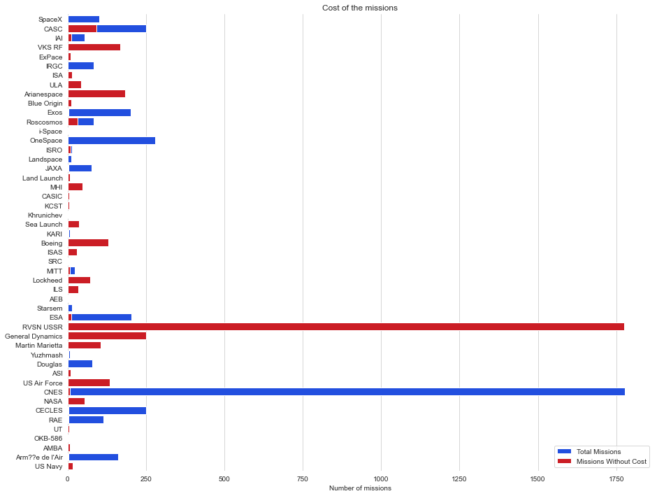

```python
df4[' Rocket'] = df4[' Rocket'].fillna(0)
mask_0 = df4[' Rocket']==0
sns.set_style(style="whitegrid")
f,ax = plt.subplots(figsize=(15,12))
sns.set_color_codes(palette="bright")
sns.countplot(y="Company Name", data=df4,
            label="Total Missions", color="b");
sns.countplot(y="Company Name", data=df4[mask_0],
            label="Missions Without Cost", color="r");
ax.legend(ncol=1, loc="lower right", frameon=True)
ax.set(ylabel="",xlabel="Number of missions")
sns.despine(left=True, bottom=True)
plt.title("Cost of the missions")
```

```python
s_data_n = s_data[~s_data[' Rocket'].isna()].copy()
s_data_n[' Rocket'] = s_data_n[' Rocket'].replace('5,000.0 ',500)
s_data_n[' Rocket'] = s_data_n[' Rocket'].replace('1,160.0 ',116)
s_data_n[' Rocket'] = s_data_n[' Rocket'].astype('float64')
```

Feature Correlations

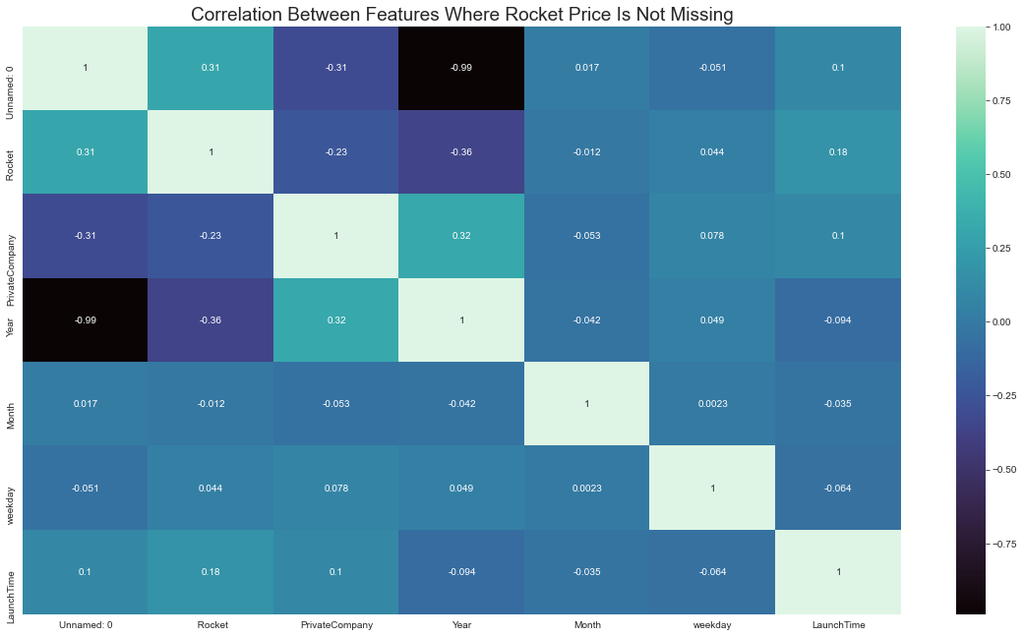

```python
sn_cor = s_data_n.corr()
plt.figure(figsize=(20,11))
ax = sns.heatmap(sn_cor,annot=True,cmap='mako')
ax.set_title('Correlation Between Features Where Rocket Price Is Not Missing',fontsize=19)
plt.show()
```

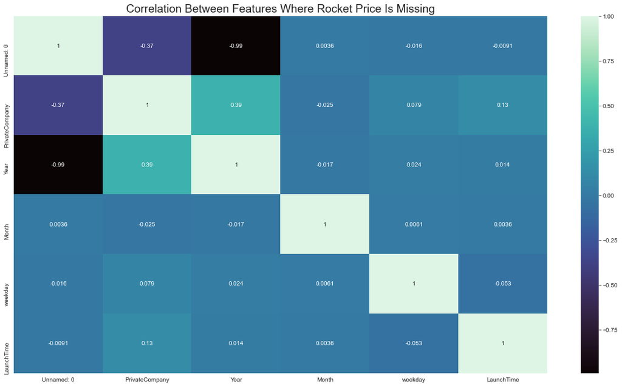

```python
sn_cor = s_data.corr()
plt.figure(figsize=(20,11))
ax = sns.heatmap(sn_cor,annot=True,cmap='mako')
ax.set_title('Correlation Between Features Where Rocket Price Is Missing',fontsize=19)
plt.show()
```

When looking in the whole data including the missing price values we see that it confirms the correlation we saw in the smaller sample of this population in the perivous heatmap shown above

Years from last start

```python
res = list()
for group in df3.groupby(['Company Name']):
    res.append(group[1][['Company Name', 'Year']].head(1))

data = pd.concat(res)
data = data.sort_values('Year')
data['Year'] = 2020 - data['Year']

fig = px.bar(
    data,
    x="Year",
    y="Company Name",
    orientation='h',
    title='Number of years from last launch',
    width=1000,
    height=1000,
    template = "plotly"
)

fig.show()
```

[interactive chart not shown]

```python
private_company = ['SpaceX', 'ULA', 'Northrop', 'Rocket Lab', 'Virgin Orbit', 'MHI', 'Arianespace', 'Blue Origin',
                   'Exos', 'ILS', 'i-Space', 'OneSpace', 'Landspace', 'Eurockot', 'Land Launch', 'Kosmotras',
                   'Sea Launch', 'Boeing', 'SRC', 'Lockheed', 'Starsem', 'General Dynamics', 'Martin Marietta',
                   'Douglas', 'AMBA']
dataset_private = df[df['Company Name'].isin(private_company)]
dataset_public = df[~df['Company Name'].isin(private_company)]
df['PrivateCompany'] = df['Company Name'].isin(private_company)
```

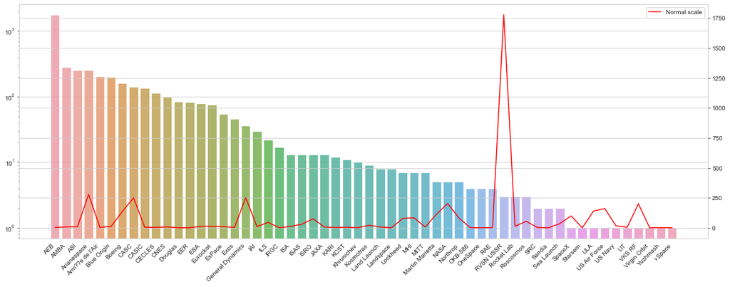

```
The ten first private companies are : Company Name
Arianespace         279
General Dynamics    251
ULA                 140
Boeing              136
Martin Marietta     114
SpaceX              100
MHI                  84
Northrop             83
Lockheed             79
ILS                  46
Name: Launch per private company, dtype: int64

count     25.000000
mean      57.440000
std       77.502194
min        1.000000
25%        3.000000
50%       13.000000
75%       84.000000
max      279.000000
Name: Launch per private company, dtype: float64

count      31.000000
mean       93.161290
std       319.903329
min         1.000000
25%         3.000000
50%         7.000000
75%        23.500000
max      1777.000000
Name: Launch per public company, dtype: float64
```

```python
company_count = space_data['Company Name'].value_counts()
#company_count = company_count.loc(company_count['values'] >= 9.5)
f, ax = plt.subplots(figsize=(20, 7))
ax.set(yscale="log")
ax.set_xticklabels(ax.get_xticklabels(), rotation=45, horizontalalignment='right')
sns.barplot(x=company_count.index, y=company_count.values, alpha=0.8)
ax2 = ax.twinx()
ax2.plot(sns.lineplot(x=company_count.index, y=company_count.values, color='red').plot(),label='Normal scale', color='red')
plt.legend()
plt.show()

count_per_private = space_data[space_data['PrivateCompany']==True].groupby(['Company Name']).agg('count')['Country'].rename('Launch per private company')
print('The ten first private companies are :', count_per_private.sort_values(ascending=False).head(10),'\n')
print(count_per_private.describe(),'\n')

count_per_public = space_data[space_data['PrivateCompany']==False].groupby(['Company Name']).agg('count')['Country'].rename('Launch per public company')
print(count_per_public.describe(),'\n')
```

The public sector is lead by few huge companies. The private sector has a better distribution.

A important part of small actors because a quarter of the companies has launched only three missions.

Now we will analyse the importance of the private sector for the main countries.

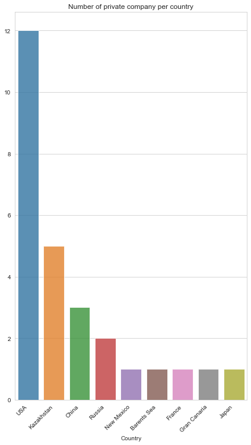

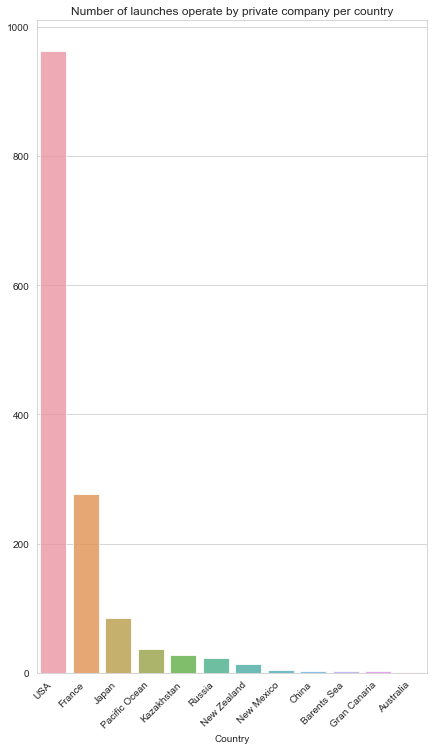

```python
company_existence = space_data.groupby(['Company Name']).agg(
    start=pd.NamedAgg('Year', min),
    end=pd.NamedAgg('Year', max)
)

nb_active_company = []
for year in range(space_data['Year'].min(), space_data['Year'].max()):
    nb = company_existence[(company_existence['start']<=year) & (company_existence['end']>=year)].count()[0]
    nb_active_company.append([year, nb])
nb_active_company = pd.DataFrame(nb_active_company,columns=['Year', 'Count'])

private_country = space_data[['Country', 'PrivateCompany', 'Company Name']].drop_duplicates(ignore_index=True)
private_country=private_country.groupby('Country').sum()['PrivateCompany'].sort_values(ascending=False).head(9)
br = sns.barplot(x=private_country.index,y=private_country.values, alpha=0.8)
br.set_xticklabels(br.get_xticklabels(), rotation=45, horizontalalignment='right')
plt.title('Number of private company per country')
plt.show()

private_launch_country = space_data[space_data['PrivateCompany']==True].groupby('Country').count()['Year'].rename('Count').sort_values(axis=0, ascending=False)
br = sns.barplot(x=private_launch_country.index,y=private_launch_country.values, alpha=0.8)
br.set_xticklabels(br.get_xticklabels(), rotation=45, horizontalalignment='right')
plt.title('Number of launches operate by private company per country')
plt.show()
```

Space Race

Space Mission Time Series (1957 - 2020)

```python
space = space_data.copy()
space['Datum'] = pd.to_datetime(space['Datum'].values)
space['Datum'] = space['Datum'].apply(lambda x : x.replace(tzinfo=None))
space['Datum'] = pd.DatetimeIndex(space['Datum'], freq=None)
data = space.groupby(space.Datum.dt.year)['Status Mission'].count()
fig = go.Figure()

data2 = space[space['Status Mission'] == 'Failure']
data2 = data2.groupby(space.Datum.dt.year)['Status Mission'].count()

data3 = space[space['Status Mission'] == 'Success']
data3 = data3.groupby(space.Datum.dt.year)['Status Mission'].count()

fig.add_trace(go.Scatter(
    x=data.index,
    y=data.values,
    showlegend=True,
    name='Space Mission',
    mode='lines+markers'
))

fig.add_trace(go.Scatter(
    x=data2.index,
    y=data2.values,
    showlegend=True,
    name='Failure Space Mission',
))

fig.add_trace(go.Scatter(
    x=data3.index,
    y=data3.values,
    showlegend=True,
    name='Success of Space Mission'
))

fig.add_annotation(

    x=1975,
    y=120,
    ax=70,
    text="Space Race End 1975",
    showarrow=True,
)


fig.update_layout(
    title_text = 'Space Mission Time Series',
    shapes=[
    dict(
      type= 'line',
      yref= 'paper', y0= 0, y1= 1,
      xref= 'x', x0= 1975, x1= 1975,
    )],
    template='plotly',
    xaxis_title='Year',
    yaxis_title='Number of Space Mission'
)
```

[interactive chart not shown]

Number of Space Mission by Space Company with atleast 100 missions

```python
data = df.groupby(['Company Name'])['Status Mission'].count().sort_values(ascending=False)
top10 = data[data.values >= 100]

data = df[df['Company Name'].isin(top10.index)]
data = data.groupby([data.Datum.dt.year, data['Company Name']])['Status Mission'].count().reset_index()

fig = px.line(x=data.Datum, y=data['Status Mission'], color=data['Company Name'])


fig.add_annotation(

    x=1975,
    y=100,
    ax=70,
    text="Space Race End 1975",
    showarrow=True,
)
fig.update_layout(
    title_text="Number of Space Mission by Space Company with atleast 100 missions",
    xaxis_title="Year",
    yaxis_title="Number of Space Mission",
    legend_title="Company Name",
    title_x=0.5,
    shapes=[
    dict(
      type= 'line',
      yref= 'paper', y0= 0, y1= 1,
      xref= 'x', x0= 1975, x1= 1975,
    )],
    template='plotly'

)

fig.show()
```

[interactive chart not shown]

Leaders by launches for every year (countries)

```python
ds = space_data.groupby(['Year', 'Country'])['Status Mission'].count().reset_index().sort_values(['Year', 'Status Mission'], ascending=False)
ds = pd.concat([group[1].head(1) for group in ds.groupby(['Year'])])
ds.columns = ['Year', 'Country', 'launches']

fig = px.bar(
    ds,
    x="Year",
    y="launches",
    color='Country',
    title='Leaders by launches for every year (countries)',
    template = "plotly",
    width = 1000,
    height = 880
)

fig.show()
```

[interactive chart not shown]

Leaders by success launches for every year (countries)

```python
ds = space_data[space_data['Status Mission']=='Success']
ds = ds.groupby(['Year', 'Country'])['Status Mission'].count().reset_index().sort_values(['Year', 'Status Mission'], ascending=False)
ds = pd.concat([group[1].head(1) for group in ds.groupby(['Year'])])
ds.columns = ['Year', 'Country', 'launches']

fig = px.bar(
    ds,
    x="Year",
    y="launches",
    color='Country',
    title='Leaders by success launches for every year (countries)',
    width = 1000,
    height = 880
)

fig.show()
```

[interactive chart not shown]

Leaders by launches for every year (companies)

```python
ds = space_data.groupby(['Year', 'Company Name'])['Status Mission'].count().reset_index().sort_values(['Year', 'Status Mission'], ascending=False)
ds = pd.concat([group[1].head(1) for group in ds.groupby(['Year'])])
ds.columns = ['Year', 'company', 'launches']

fig = px.bar(
    ds,
    x="Year",
    y="launches",
    color='company',
    title='Leaders by launches for every year (companies)',
    width = 1000,
    height = 880
)

fig.show()
```

[interactive chart not shown]

Leaders by success launches for every year (companies)

```python
ds = space_data[space_data['Status Mission']=='Success']
ds = ds.groupby(['Year', 'Company Name'])['Status Mission'].count().reset_index().sort_values(['Year', 'Status Mission'], ascending=False)
ds = pd.concat([group[1].head(1) for group in ds.groupby(['Year'])])
ds.columns = ['year', 'company', 'launches']

fig = px.bar(
    ds,
    x="year",
    y="launches",
    color='company',
    title='Leaders by success launches for every year (companies)',
    width = 1000,
    height = 880
)

fig.show()
```

[interactive chart not shown]

Most experienced companies (years of launches)

```python
ds = space_data.groupby(['Company Name'])['Year'].nunique().reset_index()

ds.columns = [
    'company',
    'count'
]

fig = px.bar(
    ds,
    x="company",
    y="count",
    title='Most experienced companies (years of launches)',
    width = 1000,
    height = 680
)

fig.show()
```

[interactive chart not shown]

top 5 companies by number of starts

```python
data = space_data.groupby(['Company Name', 'Year'])['Status Mission'].count().reset_index()

data.columns = [
    'company',
    'year',
    'starts'
]

top5 = data.groupby(['company'])['starts'].sum().reset_index().sort_values('starts', ascending=False).head(5)['company'].tolist()
```

```python
data = data[data['company'].isin(top5)]

fig = px.line(
    data,
    x="year",
    y="starts",
    title='Dynamic of top 5 companies by number of starts',
    color='company',
    template = "plotly"
)

fig.show()
```

[interactive chart not shown]

Top 10 Rockets with most mission

```python
data = space_data.groupby('Rocket Name')['Detail'].count().sort_values(ascending=False).iloc[:10].sort_values(ascending=True)

fig = px.bar(data, y=data.index, x=data.values, template='plotly')
fig.update_layout(
    title_text='Top 10 Rocket with most mission',
    title_x=0.5,
    xaxis_title='Number of mission'

)
fig.show()
```

[interactive chart not shown]

Top ten companies/organisation which have maxium numbers of rocket mission

```python
data = space_data.copy()
data['Company Name'].value_counts()
fig = px.pie(data,values = data['Company Name'].value_counts().values[:10],
             names = data['Company Name'].value_counts().index[:10]
             ,hole=.4,height = 700
            )
fig.update_traces(textinfo='label+percent',textposition='inside')
fig.update_layout(title='Top 10 Companies',
                 annotations=[dict(x=0.5,y=0.5,text='Companies',showarrow=False,font_size=20)])
fig.show()
```

[interactive chart not shown]

Top 10 Countries with Maximum Mission

```python
data['Country'].value_counts().index[:10]

fig = px.pie(data,values=data['Country'].value_counts().values[:10],
                 names = data['Country'].value_counts().index[:10],
                 title='Top 10 Countries with Maximum Mission',
                 hole=.4,height = 700
                )

fig.update_traces(textposition='inside',textinfo='label+percent')

fig.update_layout(annotations=[dict(x=.5,y=.5,text='Countries',showarrow=False,font_size=20)])

fig.show()
```

[interactive chart not shown]

Top 5 Companies with highest number of success's

```python
temp = space[space['Status Mission']== 'Success']
success =  pd.DataFrame({'count' : temp.groupby( "Company Name").size()}).reset_index()
success.sort_values(by='count', ascending=False).head()['Company Name']
```

```
35           RVSN USSR
2          Arianespace
6                 CASC
14    General Dynamics
46              VKS RF
Name: Company Name, dtype: object
```

Top 5 Companies with highest number of failures

```python
temp = space[space['Status Mission']== 'Failure']
fail =  pd.DataFrame({'count' : temp.groupby( "Company Name").size()}).reset_index()
fail.sort_values(by='count', ascending=False).head()['Company Name']
```

```
31           RVSN USSR
13    General Dynamics
38        US Air Force
4                 CASC
39             US Navy
Name: Company Name, dtype: object
```

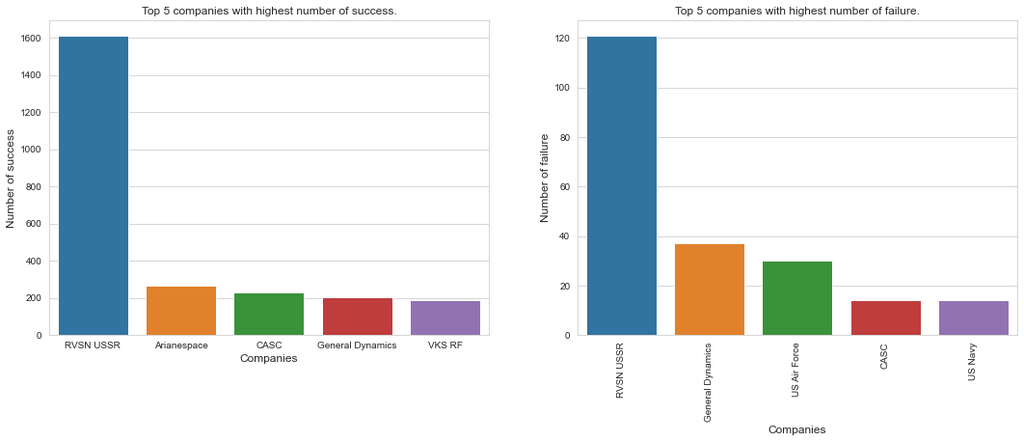

```python
fig, axes = plt.subplots(1,2,figsize=(18,6))
sns.barplot(x=success.sort_values(by='count', ascending=False).head()['Company Name'], y = success['count'], ax = axes[0])
axes[0].set_xlabel("Companies", fontsize=12)
axes[0].set_ylabel("Number of success", fontsize=12)
axes[0].set_title("Top 5 companies with highest number of success.")
sns.barplot(x=fail.sort_values(by='count', ascending=False).head()['Company Name'], y = fail['count'], ax = axes[1])
axes[1].set_xlabel("Companies", fontsize=12)
axes[1].set_ylabel("Number of failure", fontsize=12)
axes[1].set_title("Top 5 companies with highest number of failure.")
plt.xticks(rotation=90)
```

Total number of launches each year based on companies

```python
def compare_by_company(first_company, second_company):
    '''
    This method will group the data for the give company name and will render the compring line chart for the same.
    '''
    df1 = pd.DataFrame({'count_company_1' : space[space['Company Name']==first_company].groupby(by='Year').size()})
    df2 = pd.DataFrame({'count_company_2' : space[space['Company Name']==second_company].groupby(by='Year').size()})
    plt.figure(figsize=(18,9))
    plt.plot(df1['count_company_1'])
    plt.plot(df2['count_company_2'], 'r')
    plt.xticks(rotation=90)
    x_ticks = np.arange(1957, 2020, 3)
    plt.xticks(x_ticks)
    plt.xlabel('Year', fontsize=16)
    plt.ylabel('Number of launches', fontsize=16)
    plt.tick_params(labelsize=12)
    plt.title(f'Total number of launches each year : {first_company} vs {second_company}' , fontsize=16)

    plt.legend([first_company, second_company])
```

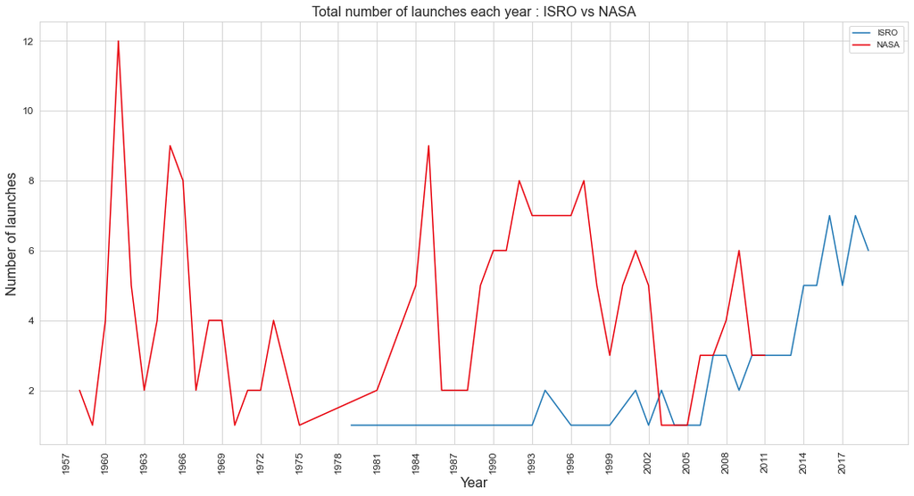

```python
compare_by_company('ISRO', 'NASA')
```

```python
def compare_by_country2(first_country, second_country):
    '''
    This method will group the data for the give country name and will render the compring line chart for the same.
    '''
    df1 = pd.DataFrame({first_country : space[space['Country']==first_country].groupby(by='Year').size()})
    df2 = pd.DataFrame({second_country : space[space['Country']==second_country].groupby(by='Year').size()})
    df = df1.join(df2)
    df.fillna(0)
    _fig = df[[first_country, second_country]].iplot(kind='scatter', xTitle="Year", yTitle = "Number of launches",
                 title='Launches based on country', asFigure=True)
    _fig.iplot()
```

```python
compare_by_country2("USA", "India")
```

[interactive chart not shown]